# Network inference

Author

Mariam Rahali Masbouri

Published

March 31, 2026

In this file, we will perform network inference on the gut microbiota datasets using three different methods: LIMITS, FlashWeave and BEEM-Static. We will first import the relevant datasets from the dysbiotic cohorts (that is, those pertaining to IBD, IBS, CRC, and CDI) as well as the healthy cohorts from the Human Microbiome Project (HMPv13 and HMPv35), NIBIOHN and MORINAGA cohorts, and a “diet intervention” cohort as well. We describe first each tool and its implementation in the following sections, and then we will compare the results obtained from each method in a final section.

For each tool, the following metrics will be computed:

where $w_{ij}^+$ and $w_{ij}^-$ denote the positive and negative edge weights between taxa i and j respectively.For directed inference tools (BEEM-Static, LIMITS), both directions $w_{ij}$ and $w_{ji}$ are included. For undirected tools (FlashWeave), each pair is counted once. The ratio remains comparable across tools as any double-counting cancels in the ratio.

# Importing the MAE object

```r
mae_file <-
  fs::dir_ls(str_c(data_dir(), "/02-processed-data"), regexp = "MAE_processed_.*\\.rds$") |>
  sort(decreasing = TRUE) |>
  magrittr::extract(1)


cat(str_c("Loading MultiAssayExperiment from: 00_data/", mae_file |> str_remove(data_dir()), "\n"))
```

```
Loading MultiAssayExperiment from: 00_data//02-processed-data/MAE_processed_20260329.rds
```

```r
mae <- readRDS(mae_file)

rm(mae_file)

mae
```

```
A MultiAssayExperiment object of 9 listed
 experiments with user-defined names and respective classes.
 Containing an ExperimentList class object of length 9:
 [1] IBD: SummarizedExperiment with 432 rows and 1630 columns
 [2] IBS: SummarizedExperiment with 598 rows and 72 columns
 [3] CDI: SummarizedExperiment with 878 rows and 366 columns
 [4] CRC: SummarizedExperiment with 837 rows and 575 columns
 [5] HMPV13: SummarizedExperiment with 660 rows and 171 columns
 [6] HMPV35: SummarizedExperiment with 1179 rows and 308 columns
 [7] NIBIOHN: SummarizedExperiment with 351 rows and 954 columns
 [8] MORINAGA: SummarizedExperiment with 281 rows and 642 columns
 [9] DIET: SummarizedExperiment with 193 rows and 114 columns
Functionality:
 experiments() - obtain the ExperimentList instance
 colData() - the primary/phenotype DataFrame
 sampleMap() - the sample coordination DataFrame
 `$`, `[`, `[[` - extract colData columns, subset, or experiment
 *Format() - convert into a long or wide DataFrame
 assays() - convert ExperimentList to a SimpleList of matrices
 exportClass() - save data to flat files
```

# Network inference with LIMITS

# Network inference with FlashWeave

In this section, we will apply FlashWeave to the different groups (healthy and diseased) separately.

FlashWeave is a network inference tool developed by the Von Mering research group (Tackmann et al., 2019). It operates within a Probabilistic Graphical Model framework, enabling the integration of metadata and the prediction of direct microbial interactions from heterogeneous microbial abundance datasets.

> TODO: Check correlation between rho and edge number, if there is a correlation, it can also corroborate why ENBI is more of a technical artefact rather than a geniune microbiome property.

We first begin by loading the Julia package FlashWeave using the `JuliaCall` package in R. This package enables us to run Julia code from R.

```r
library(JuliaCall)
julia_setup(JULIA_HOME = "C:/Users/maria/.julia/juliaup/julia-1.12.5+0.x64.w64.mingw32/bin")
julia_eval('using FlashWeave')
```

```r
julia_eval('import FlashWeave: learn_network, save_network, load_data')
```

```r
julia_eval('println(methods(learn_network))')
```

As per the original article, FlashWeave was run with its default parameters, and `heterogeneous = FALSE` was chosen, in accordance with the original article. We run FlashWeave on bootstrap iterations with the function `run_network_bootstrap()` that we defined in the R/ directory. This function takes as input a dataset in matrix form, a network inference function (in this case, `run_flashweave()`, which is also defined in the R/ directory), and the parameters for the bootstrap iterations. The function returns a list of results for each bootstrap iteration, which can be used to compute the statistics of interest (PEP, Sheldon evenness, Shannon diversity, richness, and net interactions), summarized with the function `get_stats_df()`. The parameters for the bootstrap iterations are as follows: `n_bootstrap = 100`, `subsample_pcts = c(0.6, 0.7, 0.8)`, `max_attempts = 120`, and `prevalence_threshold = 0.05`. Additionally, the parameters from `get_stats_df()` are set to `symmetric = TRUE` since FlashWeave returns undirected edges.

## IBD cohort (Lloyd-Price et al. 2019)

We first import the IBD dataset from the MAE object in the chunk code below.

```r
tmp <-
  mae[["IBD"]] |>
  assay() |>
  t() |>
  as.data.frame() |>
  rownames_to_column("uid") |>
  pivot_longer(-uid, names_to = "taxon", values_to = "rel_ab") |>
  left_join(
    mae[["IBD"]] |> colData() |> as_tibble(rownames = "uid") |> select(uid, pid, visit_num, diagnosis),
    by = join_by(uid)
  )
```

```r
tmp_healthy <- tmp |> filter(diagnosis == "nonIBD")
tmp_diseased <- tmp |> filter(diagnosis == "UC" | diagnosis == "CD")

# for healthy samples

healthy_df <-
  tmp_healthy |>
  select(uid, taxon, rel_ab) |>
  pivot_wider(names_from = taxon, values_from = rel_ab) |>
  column_to_rownames("uid") |>
  t()

# for diseased samples

diseased_df <-
  tmp_diseased |>
  select(uid, taxon, rel_ab) |>
  pivot_wider(names_from = taxon, values_from = rel_ab) |>
  column_to_rownames("uid") |>
  t()
```

### Running FlashWeave on all taxa

In the chunk code below, we run FlashWeave on all taxa for healthy and diseased samples separately, with the following parameters: `n_bootstrap = 100`, `subsample_pcts = c(0.6, 0.7, 0.8)`, `max_attempts = 120`, and `prevalence_threshold = 0.05`. This means that in each bootstrap iteration, we will subsample the data at different percentages (60%, 70%, and 80%) and run FlashWeave on the subsampled data. The `prevalence_threshold` parameter is set to 0.05, meaning that taxa that are present in less than 5% of the samples will be filtered out before running FlashWeave.

```r
# res_healthy <- run_network_bootstrap(healthy_df, run_fn = run_flashweave, n_bootstrap = 100, subsample_pcts = c(0.6, 0.7, 0.8), max_attempts = 120, prevalence_threshold = 0.05)
#
# res_diseased <- run_network_bootstrap(diseased_df, run_fn = run_flashweave, n_bootstrap = 100, subsample_pcts = c(0.6, 0.7, 0.8), max_attempts = 120, prevalence_threshold = 0.05)
```

We save the results in an RDS file for later use.

```r
# saveRDS(res_healthy, file = str_c(result_dir(), "/flashweave_res_healthy_IBD_20260328.rds"))
# saveRDS(res_diseased, file = str_c(result_dir(), "/flashweave_res_diseased_IBD_20260328.rds"))
```

The results are imported in the chunk code below.

```r
res_healthy <- readRDS(file = str_c(result_dir(), "/flashweave_res_healthy_IBD_20260328.rds"))
res_diseased <- readRDS(file = str_c(result_dir(), "/flashweave_res_diseased_IBD_20260328.rds"))
```

The results are obtained in the chunk code below.

```r
df_res_healthy <- get_stats_df(res_healthy, symmetric = TRUE)
df_res_diseased <- get_stats_df(res_diseased, symmetric = TRUE)

df_res <-
  bind_rows(
    df_res_healthy |> mutate(group = "Healthy"),
    df_res_diseased |> mutate(group = "Diseased")
  )
```

We plot the results below.

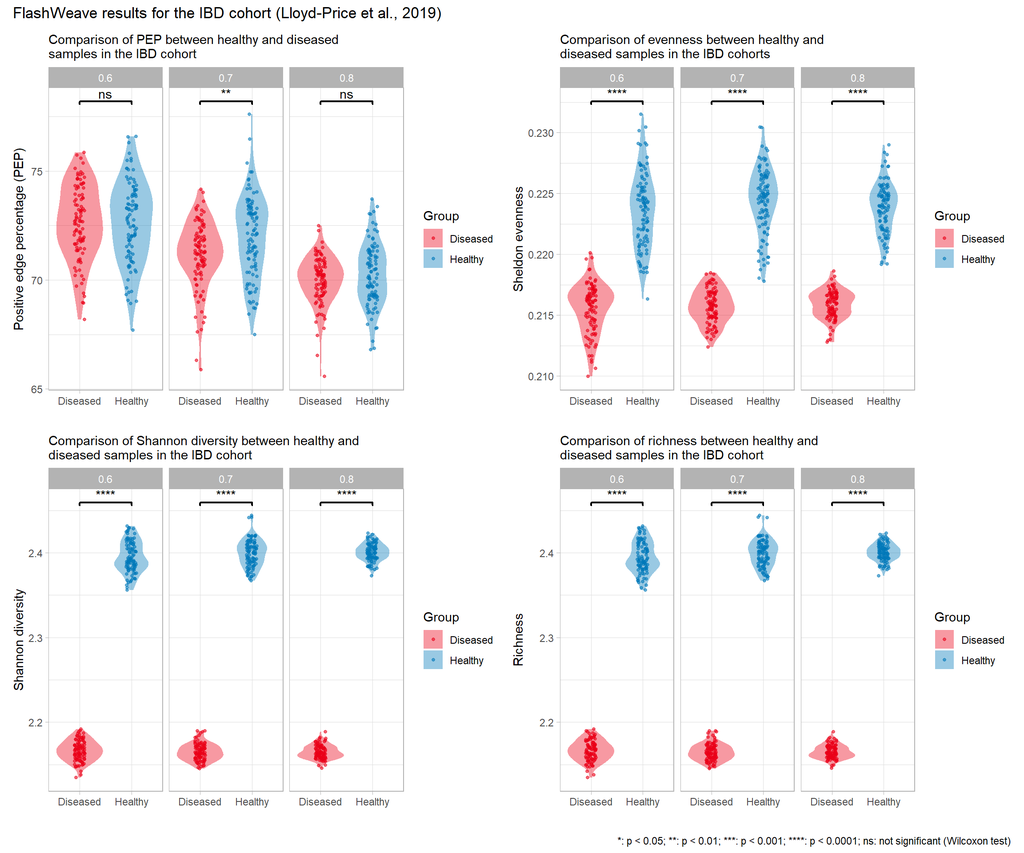

```r
# PEP plot

df_res |>
  ggplot() +
  aes(x = group, y = pep, color = group, fill = group) +
  geom_violin(alpha = 0.4, color = NA) +
  geom_point(position = position_jitter(width = 0.1), alpha = 0.6, size = 1) +
  scale_color_manual(values = c("Healthy" = "#0078B9", "Diseased" = "#EA0017")) +
  scale_fill_manual(values  = c("Healthy" = "#0078B9", "Diseased" = "#EA0017")) +
  facet_wrap(~ fraction) +
  labs(x = "", y = "Positive edge percentage (PEP)", color = "Group", fill = "Group",
       subtitle = "Comparison of PEP between healthy and diseased \nsamples in the IBD cohort") +
  stat_compare_means(
    comparisons = list(c("Healthy", "Diseased")),
    method = "wilcox.test",
    label = "p.signif",
    tip.length = 0.01,
    bracket.size = 0.8,
    fontface = "bold"
  ) +

  df_res |>
  ggplot() +
  aes(x = group, y = sheldon, color = group, fill = group) +
  geom_violin(alpha = 0.4, color = NA) +
  geom_point(position = position_jitter(width = 0.1), alpha = 0.6, size = 1) +
  scale_color_manual(values = c("Healthy" = "#0078B9", "Diseased" = "#EA0017")) +
  scale_fill_manual(values  = c("Healthy" = "#0078B9", "Diseased" = "#EA0017")) +
  facet_wrap(~ fraction) +
  labs(x = "", y = "Sheldon evenness", color = "Group", fill = "Group",
       subtitle = "Comparison of evenness between healthy and \ndiseased samples in the IBD cohorts") +
  stat_compare_means(
    comparisons = list(c("Healthy", "Diseased")),
    method = "wilcox.test",
    label = "p.signif",
    tip.length = 0.01,
    bracket.size = 0.8,
    fontface = "bold"
  ) +

# shannon diversity
df_res |>
  ggplot() +
  aes(x = group, y = shannon, color = group, fill = group) +
  geom_violin(alpha = 0.4, color = NA) +
  geom_point(position = position_jitter(width = 0.1), alpha = 0.6, size = 1) +
  scale_color_manual(values = c("Healthy" = "#0078B9", "Diseased" = "#EA0017")) +
  scale_fill_manual(values  = c("Healthy" = "#0078B9", "Diseased" = "#EA0017")) +
  facet_wrap(~ fraction) +
  labs(x = "", y = "Shannon diversity", color = "Group", fill = "Group",
       subtitle = "Comparison of Shannon diversity between healthy and \ndiseased samples in the IBD cohort") +
  stat_compare_means(
    comparisons = list(c("Healthy", "Diseased")),
    method = "wilcox.test",
    label = "p.signif",
    tip.length = 0.01,
    bracket.size = 0.8,
    fontface = "bold"
  ) +

# richness
df_res |>
  ggplot() +
  aes(x = group, y = shannon, color = group, fill = group) +
  geom_violin(alpha = 0.4, color = NA) +
  geom_point(position = position_jitter(width = 0.1), alpha = 0.6, size = 1) +
  scale_color_manual(values = c("Healthy" = "#0078B9", "Diseased" = "#EA0017")) +
  scale_fill_manual(values  = c("Healthy" = "#0078B9", "Diseased" = "#EA0017")) +
  facet_wrap(~ fraction) +
  labs(x = "", y = "Richness", color = "Group", fill = "Group",
       subtitle = "Comparison of richness between healthy and \ndiseased samples in the IBD cohort") +
  stat_compare_means(
    comparisons = list(c("Healthy", "Diseased")),
    method = "wilcox.test",
    label = "p.signif",
    tip.length = 0.01,
    bracket.size = 0.8,
    fontface = "bold"
  ) +

  patchwork::plot_layout(nrow = 2) + patchwork::plot_annotation(title = "FlashWeave results for the IBD cohort (Lloyd-Price et al., 2019)", caption = "*: p < 0.05; **: p < 0.01; ***: p < 0.001; ****: p < 0.0001; ns: not significant (Wilcoxon test)")
```

We will now check if there is any correlation between Sheldon evenness and PEP in the plot below.

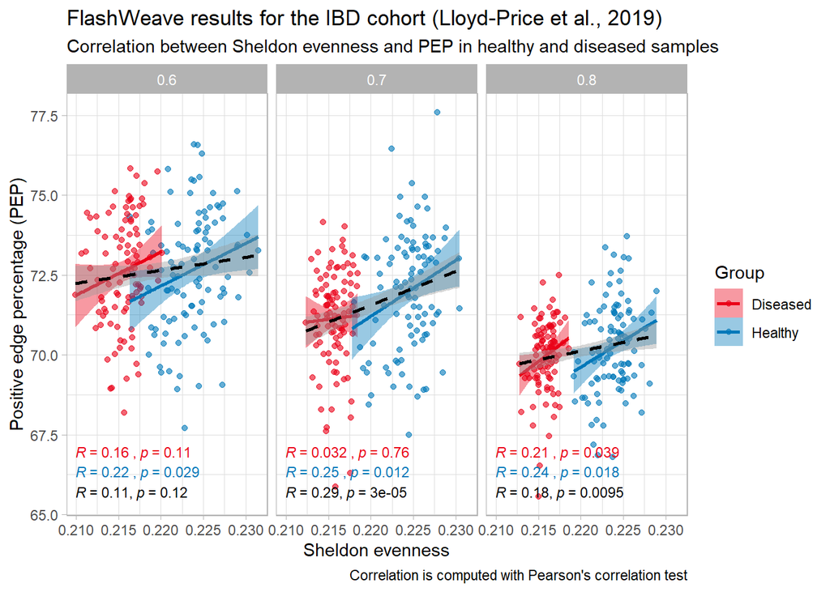

```r
df_res |>
  ggplot() +
  aes(x = sheldon, y = pep, color = group, fill = group) +
  geom_point(alpha = 0.6, size = 1.5) +
  geom_smooth(method = "lm", se = TRUE) +
  geom_smooth(aes(x = sheldon, y = pep), method = "lm",
              se = TRUE, inherit.aes = FALSE,
              color = "black", linetype = "dashed") +
  ggpubr::stat_cor(aes(label = after_stat(paste(r.label, p.label, sep = "~`,`~"))),
                   method = "pearson", label.x.npc = "left", label.y.npc = 0.12,
                   size = 3, show.legend = FALSE) +
  ggpubr::stat_cor(aes(x = sheldon, y = pep), method = "pearson",
                   inherit.aes = FALSE, color = "black",
                   label.x.npc = "left", label.y.npc = 0.015,
                   size = 3) +
  scale_color_manual(values = c("Healthy" = "#0078B9", "Diseased" = "#EA0017")) +
  scale_fill_manual(values  = c("Healthy" = "#0078B9", "Diseased" = "#EA0017")) +
  facet_wrap(~ fraction) +
  labs(x = "Sheldon evenness", y = "Positive edge percentage (PEP)", color = "Group", fill = "Group",
       title = "FlashWeave results for the IBD cohort (Lloyd-Price et al., 2019)", subtitle = "Correlation between Sheldon evenness and PEP in healthy and diseased samples", caption = "Correlation is computed with Pearson's correlation test")
```

Based on the plot, we can see a **significant positive correlation between Sheldon evenness and PEP** (except for the 60% subsampling category), meaning that samples with higher evenness tend to have a higher percentage of positive edges in the inferred network.

We also check if the results for net interactions (rho) are consistent with the PEP results, and if there is any significant difference between healthy and diseased samples in terms of net interactions.

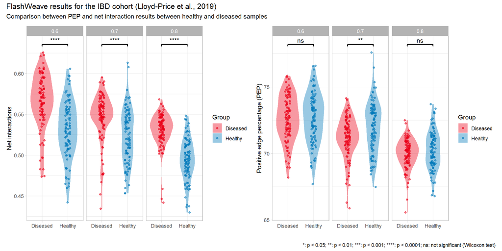

```r
df_res |>
  ggplot() +
  aes(x = group, y = rho, color = group, fill = group) +
  geom_violin(alpha = 0.4, color = NA) +
  geom_point(position = position_jitter(width = 0.1), alpha = 0.6) +
  scale_color_manual(values = c("Healthy" = "#0078B9", "Diseased" = "#EA0017")) +
  scale_fill_manual(values  = c("Healthy" = "#0078B9", "Diseased" = "#EA0017")) +
  facet_wrap(~ fraction) +
  labs(x = "", y = "Net interactions", color = "Group", fill = "Group") +
  stat_compare_means(
    comparisons = list(c("Healthy", "Diseased")),
    method = "wilcox.test",
    label = "p.signif",
    tip.length = 0.01,
    bracket.size = 0.8,
    fontface = "bold"
  ) +

  df_res |>
  ggplot() +
  aes(x = group, y = pep, color = group, fill = group) +
  geom_violin(alpha = 0.4, color = NA) +
  geom_point(position = position_jitter(width = 0.1), alpha = 0.6) +
  scale_color_manual(values = c("Healthy" = "#0078B9", "Diseased" = "#EA0017")) +
  scale_fill_manual(values  = c("Healthy" = "#0078B9", "Diseased" = "#EA0017")) +
  facet_wrap(~ fraction) +
  labs(x = "", y = "Positive edge percentage (PEP)", color = "Group", fill = "Group") +
  stat_compare_means(
    comparisons = list(c("Healthy", "Diseased")),
    method = "wilcox.test",
    label = "p.signif",
    tip.length = 0.01,
    bracket.size = 0.8,
    fontface = "bold"
  ) +

patchwork::plot_layout(nrow = 1) + patchwork::plot_annotation(title = "FlashWeave results for the IBD cohort (Lloyd-Price et al., 2019)", subtitle = "Comparison between PEP and net interaction results between healthy and diseased samples", caption = "*: p < 0.05; **: p < 0.01; ***: p < 0.001; ****: p < 0.0001; ns: not significant (Wilcoxon test)")
```

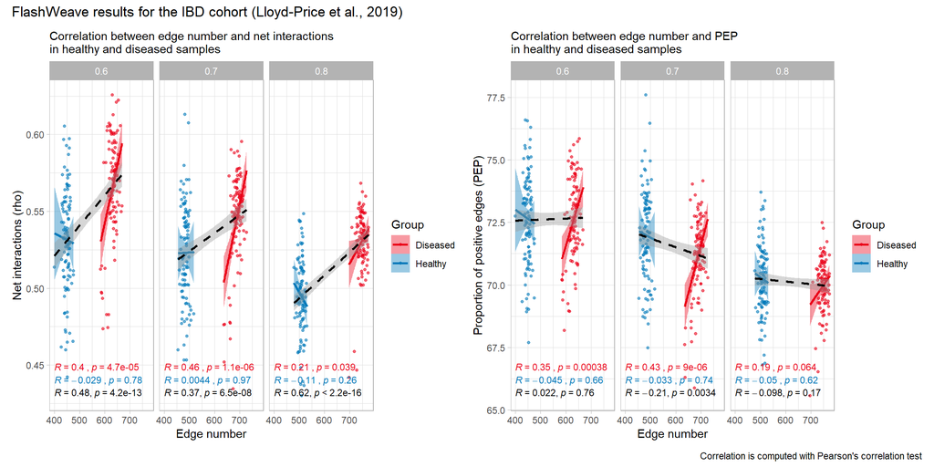

```r
df_res |>
  ggplot() +
  aes(x = edge_num, y = rho, color = group, fill = group) +
  geom_point(alpha = 0.6, size = 1) +
  geom_smooth(method = "lm", se = TRUE) +
  geom_smooth(aes(x = edge_num, y = rho), method = "lm",
              se = TRUE, inherit.aes = FALSE,
              color = "black", linetype = "dashed") +
  ggpubr::stat_cor(aes(label = after_stat(paste(r.label, p.label, sep = "~`,`~"))),
                   method = "pearson", label.x.npc = "left", label.y.npc = 0.10,
                   size = 3, show.legend = FALSE) +
  ggpubr::stat_cor(aes(x = edge_num, y = rho), method = "pearson",
                   inherit.aes = FALSE, color = "black",
                   label.x.npc = "left", label.y.npc = 0.015,
                   size = 3) +
  scale_color_manual(values = c("Healthy" = "#0078B9", "Diseased" = "#EA0017")) +
  scale_fill_manual(values  = c("Healthy" = "#0078B9", "Diseased" = "#EA0017")) +
  facet_wrap(~ fraction) +
  labs(x = "Edge number", y = "Net interactions (rho)", color = "Group", fill = "Group",
       subtitle = "Correlation between edge number and net interactions \nin healthy and diseased samples") +

  df_res |>
  ggplot() +
  aes(x = edge_num, y = pep, color = group, fill = group) +
  geom_point(alpha = 0.6, size = 1) +
  geom_smooth(method = "lm", se = TRUE) +
  geom_smooth(aes(x = edge_num, y = pep), method = "lm",
              se = TRUE, inherit.aes = FALSE,
              color = "black", linetype = "dashed") +
  ggpubr::stat_cor(aes(label = after_stat(paste(r.label, p.label, sep = "~`,`~"))),
                   method = "pearson", label.x.npc = "left", label.y.npc = 0.10,
                   size = 3, show.legend = FALSE) +
  ggpubr::stat_cor(aes(x = edge_num, y = pep), method = "pearson",
                   inherit.aes = FALSE, color = "black",
                   label.x.npc = "left", label.y.npc = 0.015,
                   size = 3) +
  scale_color_manual(values = c("Healthy" = "#0078B9", "Diseased" = "#EA0017")) +
  scale_fill_manual(values  = c("Healthy" = "#0078B9", "Diseased" = "#EA0017")) +
  facet_wrap(~ fraction) +
  labs(x = "Edge number", y = "Proportion of positive edges (PEP)", color = "Group", fill = "Group",
      subtitle = "Correlation between edge number and PEP \nin healthy and diseased samples") +

patchwork::plot_layout(nrow = 1) + patchwork::plot_annotation(title = "FlashWeave results for the IBD cohort (Lloyd-Price et al., 2019)", caption = "Correlation is computed with Pearson's correlation test")
```

We will check correlation between net interaction and Sheldon evenness in the plot below.

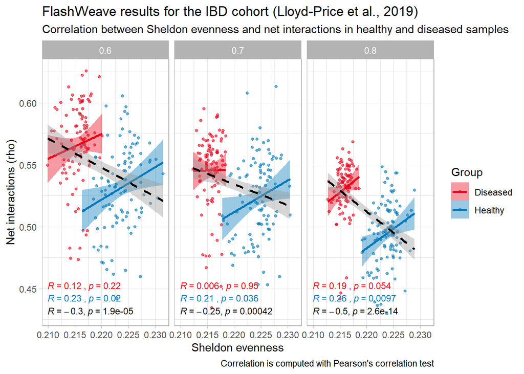

```r
df_res |>
  ggplot() +
  aes(x = sheldon, y = rho, color = group, fill = group) +
  geom_point(alpha = 0.6, size = 1) +
  geom_smooth(method = "lm", se = TRUE) +
  geom_smooth(aes(x = sheldon, y = rho), method = "lm",
              se = TRUE, inherit.aes = FALSE,
              color = "black", linetype = "dashed") +
  ggpubr::stat_cor(aes(label = after_stat(paste(r.label, p.label, sep = "~`,`~"))),
                   method = "pearson", label.x.npc = "left", label.y.npc = 0.12,
                   size = 3, show.legend = FALSE) +
  ggpubr::stat_cor(aes(x = sheldon, y = rho), method = "pearson",
                   inherit.aes = FALSE, color = "black",
                   label.x.npc = "left", label.y.npc = 0.015,
                   size = 3) +
  scale_color_manual(values = c("Healthy" = "#0078B9", "Diseased" = "#EA0017")) +
  scale_fill_manual(values  = c("Healthy" = "#0078B9", "Diseased" = "#EA0017")) +
  facet_wrap(~ fraction) +
  labs(x = "Sheldon evenness", y = "Net interactions (rho)", color = "Group", fill = "Group",
       title = "FlashWeave results for the IBD cohort (Lloyd-Price et al., 2019)", subtitle = "Correlation between Sheldon evenness and net interactions in healthy and diseased samples", caption = "Correlation is computed with Pearson's correlation test")
```

This plot shows a **significant negative correlation between Sheldon evenness and net interactions**, meaning that samples with higher evenness tend to have more negative net interactions. This is consistent with our hypothesis that samples with lower evenness tend to have more proportion of positive edges since negative edges are lost with unevenness. However, this would have been true only if we have seen a significant positive correlation between Sheldon evenness and PEP, which is not the case for all subsampling categories. This suggests that while evenness may be a confounding factor in the observed difference in net interactions between healthy and diseased samples, it does not fully explain the observed difference in PEP between the two groups.

We construct a linear model with `lm()` to check if condition across groups is still significant to explain differences in net interactions, after controlling for Sheldon evenness, Shannon diversity and richness.

```r
df_res |>
  mutate(group = factor(group, levels = c("Healthy", "Diseased"))) |>
  group_by(fraction) |>
  group_modify(~ broom::tidy(lm(rho ~ sheldon + shannon + richness + group, data = .x))) |>
  filter(term != "(Intercept)") |>
  select(fraction, term, estimate, p.value) |>
  mutate(significant = p.value < 0.05) |>
  gt(caption = "Linear model results for the association between net interactions (rho) and group, controlling for Sheldon evenness, Shannon diversity and richness")
```

Linear model results for the association between net interactions (rho) and group, controlling for Sheldon evenness, Shannon diversity and richness

| term | estimate | p.value | significant |
| --- | --- | --- | --- |
| 0.6 |  |  |  |
| sheldon | 8.27079523 | 1.162295e-10 | TRUE |
| shannon | -1.73578514 | 4.628669e-11 | TRUE |
| richness | 0.02367330 | 1.093426e-03 | TRUE |
| groupDiseased | -0.10728427 | 5.548465e-03 | TRUE |
| 0.7 |  |  |  |
| sheldon | 9.08672268 | 4.326205e-09 | TRUE |
| shannon | -1.94317862 | 9.470824e-09 | TRUE |
| richness | 0.02528055 | 7.580820e-03 | TRUE |
| groupDiseased | -0.15157427 | 7.019173e-04 | TRUE |
| 0.8 |  |  |  |
| sheldon | 8.15699916 | 2.604896e-09 | TRUE |
| shannon | -1.59683219 | 3.980164e-08 | TRUE |
| richness | 0.02393899 | 9.807725e-03 | TRUE |
| groupDiseased | -0.08131714 | 1.090340e-01 | FALSE |

The results show that the condition (group) is not significantly associated with net interactions in 80% subsampling category after controlling for Sheldon evenness, Shannon diversity and richness, suggesting that the observed difference in net interactions between healthy and diseased samples may be explained by differences in evenness, diversity and richness between the two groups.

### Running FlashWeave on top taxa

We will now perform the network analysis on top taxa selected based on their relative abundance. We select a data-driven threshold for relative abundance, which is shown in the plot below. We will keep taxa with a mean relative abundance of at least 0.001 (that is, log10 mean relative abundance of -3). This threshold correspond to the moment when the count starts to drop. Taxa with a mean relative abundance below this threshold will be grouped in a category named “Other”. This is done in the chunk code below.

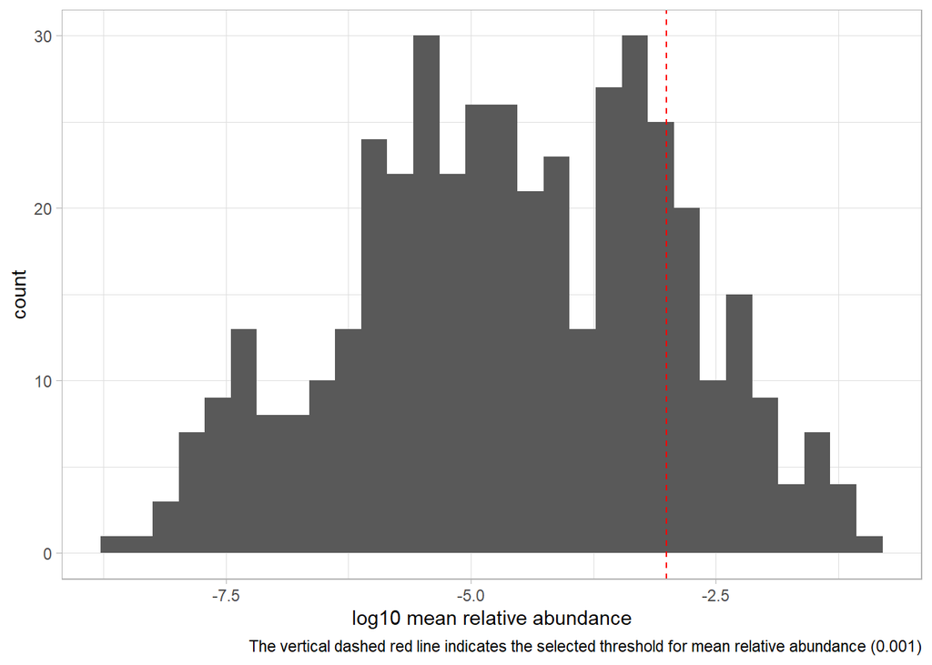

```r
# find data-driven threshold for relative abundance

tmp |>
  group_by(taxon) |>
  summarise(mean_rel_ab = mean(rel_ab)) |>
  arrange(desc(mean_rel_ab)) |>
  ggplot() +
  aes(x = mean_rel_ab |> log10()) +
  geom_histogram(bins = 30) +
  geom_vline(xintercept = -3, linetype = "dashed", color = "red") +
  labs(x = "log10 mean relative abundance", y = "count",
       caption = "The vertical dashed red line indicates the selected threshold for mean relative abundance (0.001)")
```

```r
# filter taxa based on mean relative abundance

tmp_filtered_healthy_top <-
  filter_abundance(tmp_healthy, abundance_threshold = 0.001) |>
  left_join(
    mae[["IBD"]] |> colData() |> as_tibble(rownames = "uid") |> select(uid, pid, visit_num, diagnosis),
    by = join_by(uid)
  )
```

```
Keeping 74 out of 432 taxa with mean abundance >= 0.001
```

```r
tmp_filtered_diseased_top <-
  filter_abundance(tmp_diseased, abundance_threshold = 0.001) |>
  left_join(
    mae[["IBD"]] |> colData() |> as_tibble(rownames = "uid") |> select(uid, pid, visit_num, diagnosis),
    by = join_by(uid)
  )
```

```
Keeping 80 out of 432 taxa with mean abundance >= 0.001
```

```r
healthy_df_top <-
  tmp_filtered_healthy_top |>
  select(uid, taxon, rel_ab) |>
  pivot_wider(names_from = taxon, values_from = rel_ab) |>
  column_to_rownames("uid") |>
  t()

diseased_df_top <-
  tmp_filtered_diseased_top |>
  select(uid, taxon, rel_ab) |>
  pivot_wider(names_from = taxon, values_from = rel_ab) |>
  column_to_rownames("uid") |>
  t()
```

```r
# res_healthy_top <- run_network_bootstrap(healthy_df_top, run_fn = run_flashweave, n_bootstrap = 100, subsample_pcts = c(0.6, 0.7, 0.8), max_attempts = 120, prevalence_threshold = 0)
# res_diseased_top <- run_network_bootstrap(diseased_df_top, run_fn = run_flashweave, n_bootstrap = 100, subsample_pcts = c(0.6, 0.7, 0.8), max_attempts = 120, prevalence_threshold = 0)

# saveRDS(res_healthy_top, file = str_c(result_dir(), "/flashweave_res_healthy_top_IBD_20260328.rds"))
# saveRDS(res_diseased_top, file = str_c(result_dir(), "/flashweave_res_diseased_top_IBD_20260328.rds"))
```

We load the results in the chunk code below.

```r
res_healthy_top <- readRDS(file = str_c(result_dir(), "/flashweave_res_healthy_top_IBD_20260328.rds"))
res_diseased_top <- readRDS(file = str_c(result_dir(), "/flashweave_res_diseased_top_IBD_20260328.rds"))
```

The results are obtained in the chunk code below.

```r
df_res_healthy_top <- get_stats_df(res_healthy_top, symmetric = TRUE)
df_res_diseased_top <- get_stats_df(res_diseased_top, symmetric = TRUE)

df_res_top <-
  bind_rows(
    df_res_healthy_top |> mutate(group = "Healthy"),
    df_res_diseased_top |> mutate(group = "Diseased")
  )
```

We plot the results below.

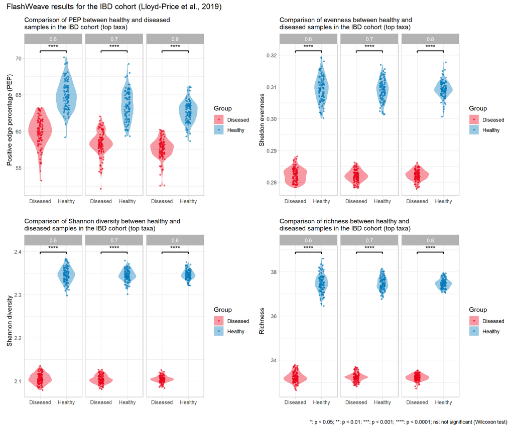

```r
# PEP plot

df_res_top |>
  ggplot() +
  aes(x = group, y = pep, color = group, fill = group) +
  geom_violin(alpha = 0.4, color = NA) +
  geom_point(position = position_jitter(width = 0.1), alpha = 0.6, size = 1) +
  scale_color_manual(values = c("Healthy" = "#0078B9", "Diseased" = "#EA0017")) +
  scale_fill_manual(values  = c("Healthy" = "#0078B9", "Diseased" = "#EA0017")) +
  facet_wrap(~ fraction) +
  labs(x = "", y = "Positive edge percentage (PEP)", color = "Group", fill = "Group",
       subtitle = "Comparison of PEP between healthy and diseased \nsamples in the IBD cohort (top taxa)") +
  stat_compare_means(
    comparisons = list(c("Healthy", "Diseased")),
    method = "wilcox.test",
    label = "p.signif",
    tip.length = 0.01,
    bracket.size = 0.8,
    fontface = "bold"
  ) +

df_res_top |>
  ggplot() +
  aes(x = group, y = sheldon, color = group, fill = group) +
  geom_violin(alpha = 0.4, color = NA) +
  geom_point(position = position_jitter(width = 0.1), alpha = 0.6, size = 1) +
  scale_color_manual(values = c("Healthy" = "#0078B9", "Diseased" = "#EA0017")) +
  scale_fill_manual(values  = c("Healthy" = "#0078B9", "Diseased" = "#EA0017")) +
  facet_wrap(~ fraction) +
  labs(x = "", y = "Sheldon evenness", color = "Group", fill = "Group",
       subtitle = "Comparison of evenness between healthy and \ndiseased samples in the IBD cohort (top taxa)") +
  stat_compare_means(
    comparisons = list(c("Healthy", "Diseased")),
    method = "wilcox.test",
    label = "p.signif",
    tip.length = 0.01,
    bracket.size = 0.8,
    fontface = "bold"
  ) +

# shannon diversity
df_res_top |>
  ggplot() +
  aes(x = group, y = shannon, color = group, fill = group) +
  geom_violin(alpha = 0.4, color = NA) +
  geom_point(position = position_jitter(width = 0.1), alpha = 0.6, size = 1) +
  scale_color_manual(values = c("Healthy" = "#0078B9", "Diseased" = "#EA0017")) +
  scale_fill_manual(values  = c("Healthy" = "#0078B9", "Diseased" = "#EA0017")) +
  facet_wrap(~ fraction) +
  labs(x = "", y = "Shannon diversity", color = "Group", fill = "Group",
       subtitle = "Comparison of Shannon diversity between healthy and \ndiseased samples in the IBD cohort (top taxa)") +
  stat_compare_means(
    comparisons = list(c("Healthy", "Diseased")),
    method = "wilcox.test",
    label = "p.signif",
    tip.length = 0.01,
    bracket.size = 0.8,
    fontface = "bold"
  ) +

# richness
df_res_top |>
  ggplot() +
  aes(x = group, y = richness, color = group, fill = group) +
  geom_violin(alpha = 0.4, color = NA) +
  geom_point(position = position_jitter(width = 0.1), alpha = 0.6, size = 1) +
  scale_color_manual(values = c("Healthy" = "#0078B9", "Diseased" = "#EA0017")) +
  scale_fill_manual(values  = c("Healthy" = "#0078B9", "Diseased" = "#EA0017")) +
  facet_wrap(~ fraction) +
  labs(x = "", y = "Richness", color = "Group", fill = "Group",
       subtitle = "Comparison of richness between healthy and \ndiseased samples in the IBD cohort (top taxa)") +
  stat_compare_means(
    comparisons = list(c("Healthy", "Diseased")),
    method = "wilcox.test",
    label = "p.signif",
    tip.length = 0.01,
    bracket.size = 0.8,
    fontface = "bold"
  ) +

  patchwork::plot_layout(nrow = 2) + patchwork::plot_annotation(title = "FlashWeave results for the IBD cohort (Lloyd-Price et al., 2019)", caption = "*: p < 0.05; **: p < 0.01; ***: p < 0.001; ****: p < 0.0001; ns: not significant (Wilcoxon test)")
```

In those plots, we can see that there is a significant difference in PEP between healthy and diseased samples, with **healthy samples having a higher PEP compared to diseased samples**. There is also a significant difference in Sheldon evenness, Shannon diversity and richness between the two groups, with **healthy samples having higher evenness, diversity and richness compared to diseased samples**, consistent with the results found with all taxa.

We will now check if there is any correlation between Sheldon evenness and PEP in the plot below.

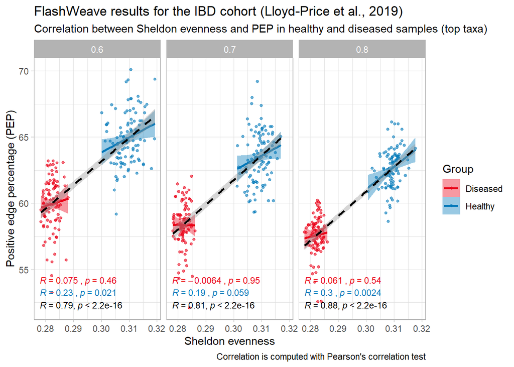

```r
df_res_top |>
  ggplot() +
  aes(x = sheldon, y = pep, color = group, fill = group) +
  geom_point(alpha = 0.6, size = 1) +
  geom_smooth(method = "lm", se = TRUE) +
  geom_smooth(aes(x = sheldon, y = pep), method = "lm",
              se = TRUE, inherit.aes = FALSE,
              color = "black", linetype = "dashed") +
  ggpubr::stat_cor(aes(label = after_stat(paste(r.label, p.label, sep = "~`,`~"))),
                   method = "pearson", label.x.npc = "left", label.y.npc = 0.12,
                   size = 3, show.legend = FALSE) +
  ggpubr::stat_cor(aes(x = sheldon, y = pep), method = "pearson",
                   inherit.aes = FALSE, color = "black",
                   label.x.npc = "left", label.y.npc = 0.015,
                   size = 3) +
  scale_color_manual(values = c("Healthy" = "#0078B9", "Diseased" = "#EA0017")) +
  scale_fill_manual(values  = c("Healthy" = "#0078B9", "Diseased" = "#EA0017")) +
  facet_wrap(~ fraction) +
  labs(x = "Sheldon evenness", y = "Positive edge percentage (PEP)", color = "Group", fill = "Group",
       title = "FlashWeave results for the IBD cohort (Lloyd-Price et al., 2019)", subtitle = "Correlation between Sheldon evenness and PEP in healthy and diseased samples (top taxa)", caption = "Correlation is computed with Pearson's correlation test")
```

We also check if the results for net interactions (rho) are consistent with the PEP results, and if there is any significant difference between healthy and diseased samples in terms of net interactions.

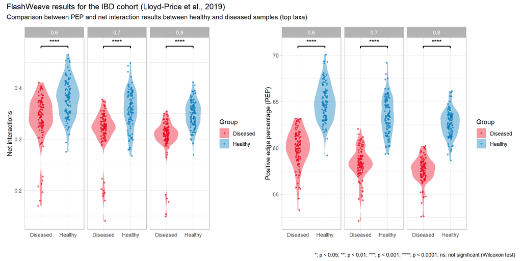

```r
df_res_top |>
  ggplot() +
  aes(x = group, y = rho, color = group, fill = group) +
  geom_violin(alpha = 0.4, color = NA) +
  geom_point(position = position_jitter(width = 0.1), alpha = 0.6, size = 1) +
  scale_color_manual(values = c("Healthy" = "#0078B9", "Diseased" = "#EA0017")) +
  scale_fill_manual(values  = c("Healthy" = "#0078B9", "Diseased" = "#EA0017")) +
  facet_wrap(~ fraction) +
  labs(x = "", y = "Net interactions", color = "Group", fill = "Group") +
  stat_compare_means(
    comparisons = list(c("Healthy", "Diseased")),
    method = "wilcox.test",
    label = "p.signif",
    tip.length = 0.01,
    bracket.size = 0.8,
    fontface = "bold"
  ) +

df_res_top |>
  ggplot() +
  aes(x = group, y = pep, color = group, fill = group) +
  geom_violin(alpha = 0.4, color = NA) +
  geom_point(position = position_jitter(width = 0.1), alpha = 0.6, size = 1) +
  scale_color_manual(values = c("Healthy" = "#0078B9", "Diseased" = "#EA0017")) +
  scale_fill_manual(values  = c("Healthy" = "#0078B9", "Diseased" = "#EA0017")) +
  facet_wrap(~ fraction) +
  labs(x = "", y = "Positive edge percentage (PEP)", color = "Group", fill = "Group") +
  stat_compare_means(
    comparisons = list(c("Healthy", "Diseased")),
    method = "wilcox.test",
    label = "p.signif",
    tip.length = 0.01,
    bracket.size = 0.8,
    fontface = "bold"
  ) +

patchwork::plot_layout(nrow = 1) + patchwork::plot_annotation(title = "FlashWeave results for the IBD cohort (Lloyd-Price et al., 2019)", subtitle = "Comparison between PEP and net interaction results between healthy and diseased samples (top taxa)", caption = "*: p < 0.05; **: p < 0.01; ***: p < 0.001; ****: p < 0.0001; ns: not significant (Wilcoxon test)")
```

In these plots, we can see that there is a significant difference in net interactions between healthy and diseased samples, with **healthy samples having more positive net interactions compared to diseased samples**. This is consistent with the PEP results, which also showed a significant difference between the two groups, but not consistent with the results obtained with all taxa.

We will check correlation between net interaction and Sheldon evenness in the plot below.

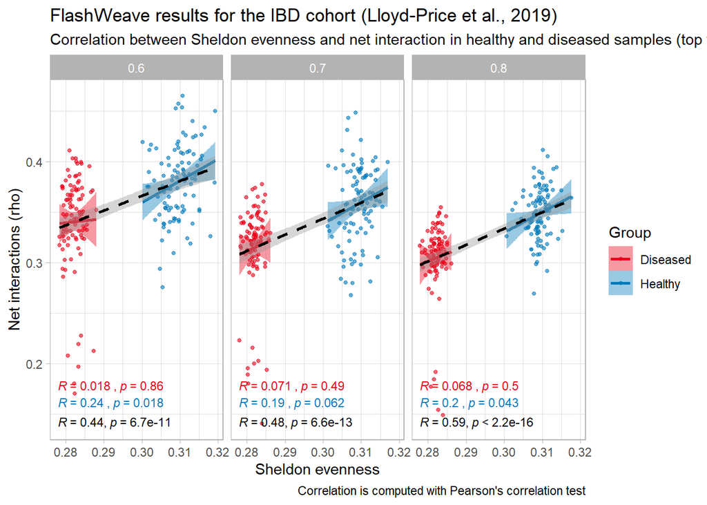

```r
df_res_top |>
  ggplot() +
  aes(x = sheldon, y = rho, color = group, fill = group) +
  geom_point(alpha = 0.6, size = 1) +
  geom_smooth(method = "lm", se = TRUE) +
  geom_smooth(aes(x = sheldon, y = rho), method = "lm",
              se = TRUE, inherit.aes = FALSE,
              color = "black", linetype = "dashed") +
  ggpubr::stat_cor(aes(label = after_stat(paste(r.label, p.label, sep = "~`,`~"))),
                   method = "pearson", label.x.npc = "left", label.y.npc = 0.12,
                   size = 3, show.legend = FALSE) +
  ggpubr::stat_cor(aes(x = sheldon, y = rho), method = "pearson",
                   inherit.aes = FALSE, color = "black",
                   label.x.npc = "left", label.y.npc = 0.01,
                   size = 3) +
  scale_color_manual(values = c("Healthy" = "#0078B9", "Diseased" = "#EA0017")) +
  scale_fill_manual(values  = c("Healthy" = "#0078B9", "Diseased" = "#EA0017")) +
  facet_wrap(~ fraction) +
  labs(x = "Sheldon evenness", y = "Net interactions (rho)", color = "Group", fill = "Group",
       title = "FlashWeave results for the IBD cohort (Lloyd-Price et al., 2019)", subtitle = "Correlation between Sheldon evenness and net interaction in healthy and diseased samples (top taxa)", caption = "Correlation is computed with Pearson's correlation test")
```

## IBS cohort (Mars et al., 2020)

We first import the IBS dataset from the MAE object in the chunk code below.

```r
tmp <-
  mae[["IBS"]] |>
  assay() |>
  t() |>
  as.data.frame() |>
  rownames_to_column("uid") |>
  pivot_longer(-uid, names_to = "taxon", values_to = "count") |>
  group_by(uid) |>
  mutate(rel_ab = count/sum(count)) |>
  left_join(
    mae[["IBS"]] |> colData() |> as_tibble(rownames = "uid") |> select(uid, pid, time, cohort),
    by = join_by(uid)
  )
```

We filter the data to keep only healthy and diseased samples, and we prepare the data for FlashWeave by creating two separate data frames for healthy and diseased samples, where rows correspond to taxa and columns correspond to samples. The values in the data frames are the relative abundances of the taxa in each sample. This is done in the chunk code below.

```r
tmp_healthy <- tmp |> filter(cohort == "H")
tmp_diseased <- tmp |> filter(cohort == "C" | cohort == "D")

# for healthy samples

healthy_df <-
  tmp_healthy |>
  select(uid, taxon, rel_ab) |>
  pivot_wider(names_from = taxon, values_from = rel_ab) |>
  column_to_rownames("uid") |>
  t()

# for diseased samples

diseased_df <-
  tmp_diseased |>
  select(uid, taxon, rel_ab) |>
  pivot_wider(names_from = taxon, values_from = rel_ab) |>
  column_to_rownames("uid") |>
  t()
```

```r
# res_healthy <- run_network_bootstrap(healthy_df, run_fn = run_flashweave, n_bootstrap = 100, subsample_pcts = c(0.8, 0.9), max_attempts = 120)
# res_diseased <- run_network_bootstrap(diseased_df, run_fn = run_flashweave, n_bootstrap = 100, subsample_pcts = c(0.7, 0.8), max_attempts = 120)

# saveRDS(res_healthy, file = str_c(result_dir(), "/flashweave_res_healthy_IBS_20260324.rds"))
# saveRDS(res_diseased, file = str_c(result_dir(), "/flashweave_res_diseased_IBS_20260324.rds"))
```

**Important**

The IBS cohort has only 21 samples for the healthy cohorts, which is not sufficient to run FlashWeave with the selected parameters. A solution can be to modify the `max_k` parameter, at the cost of inflating the number of indirect edges.

## CDI cohort (Ferretti et al., 2023)

We import the CDI dataset from the MAE object in the chunk code below.

```r
tmp <-
  mae[["CDI"]] |>
  assay() |>
  t() |>
  as.data.frame() |>
  rownames_to_column("uid") |>
  pivot_longer(-uid, names_to = "taxon", values_to = "count") |>
  group_by(uid) |>
  mutate(rel_ab = count/sum(count)) |>
  left_join(
    mae[["CDI"]] |> colData() |> as_tibble(rownames = "uid") |> select(uid, status, subject_disease_status),
    by = join_by(uid)
  ) |>
  filter(subject_disease_status == "CDI" | subject_disease_status == "CTR")
```

We filter the data to keep only healthy and diseased samples, and we prepare the data for FlashWeave by creating two separate data frames for healthy and diseased samples, where rows correspond to taxa and columns correspond to samples. The values in the data frames are the relative abundances of the taxa in each sample. This is done in the chunk code below.

```r
tmp_healthy <- tmp |> filter(subject_disease_status == "CTR")
tmp_diseased <- tmp |> filter(subject_disease_status == "CDI")

# for healthy samples

healthy_df <-
  tmp_healthy |>
  select(uid, taxon, rel_ab) |>
  pivot_wider(names_from = taxon, values_from = rel_ab) |>
  column_to_rownames("uid") |>
  t()

# for diseased samples

diseased_df <-
  tmp_diseased |>
  select(uid, taxon, rel_ab) |>
  pivot_wider(names_from = taxon, values_from = rel_ab) |>
  column_to_rownames("uid") |>
  t()
```

### Running FlashWeave on all taxa

In the chunk code below, we run FlashWeave on all taxa for healthy and diseased samples separately, with the following parameters: `n_bootstrap = 100`, `subsample_pcts = c(0.6, 0.7, 0.8)`, `max_attempts = 120`, and `prevalence_threshold = 0.05`. This means that in each bootstrap iteration, we will subsample the data at different percentages (60%, 70%, and 80%) and run FlashWeave on the subsampled data. The `prevalence_threshold` parameter is set to 0.05, meaning that taxa that are present in less than 5% of the samples will be filtered out before running FlashWeave.

```r
# res_healthy <- run_network_bootstrap(healthy_df, run_fn = run_flashweave, n_bootstrap = 100, subsample_pcts = c(0.6, 0.7, 0.8), max_attempts = 120, prevalence_threshold = 0.05)
# res_diseased <- run_network_bootstrap(diseased_df, run_fn = run_flashweave, n_bootstrap = 100, subsample_pcts = c(0.6, 0.7, 0.8), max_attempts = 120, prevalence_threshold = 0.05)
#
# saveRDS(res_healthy, file = str_c(result_dir(), "/flashweave_res_healthy_CDI_20260328.rds"))
# saveRDS(res_diseased, file = str_c(result_dir(), "/flashweave_res_diseased_CDI_20260328.rds"))
```

We load the results in the chunk code below.

```r
res_healthy <- readRDS(file = str_c(result_dir(), "/flashweave_res_healthy_CDI_20260328.rds"))
res_diseased <- readRDS(file = str_c(result_dir(), "/flashweave_res_diseased_CDI_20260328.rds"))
```

The results are obtained in the chunk code below.

```r
df_res_healthy <- get_stats_df(res_healthy, symmetric = TRUE)
df_res_diseased <- get_stats_df(res_diseased, symmetric = TRUE)

df_res <-
  bind_rows(
    df_res_healthy |> mutate(group = "Healthy"),
    df_res_diseased |> mutate(group = "Diseased")
  )
```

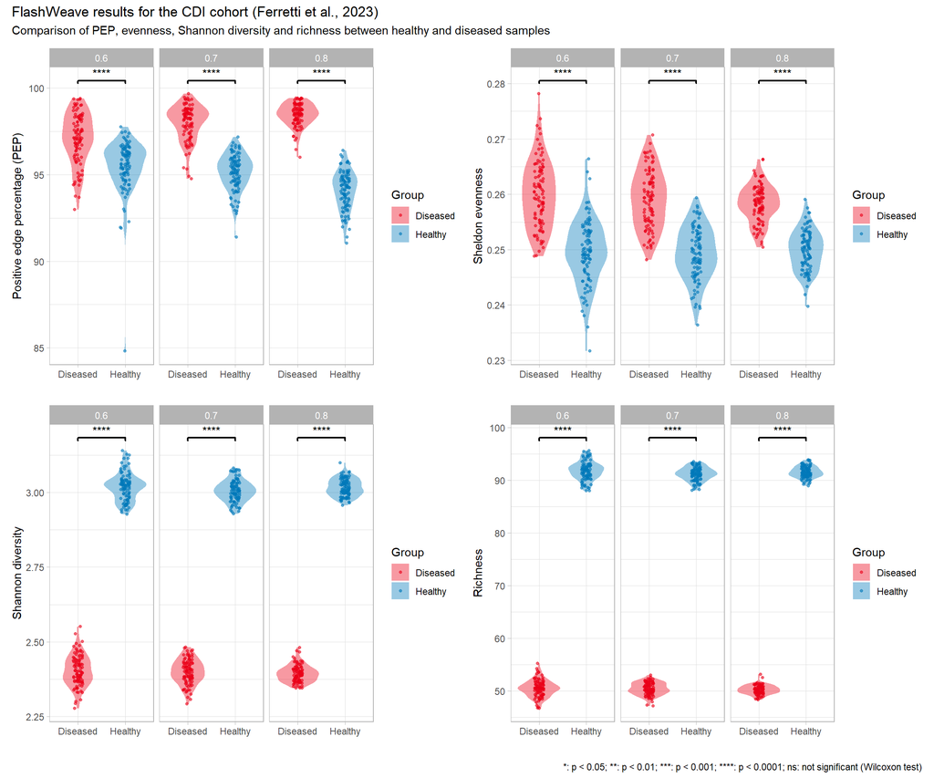

```r
df_res |>
  ggplot() +
  aes(x = group, y = pep, color = group, fill = group) +
  geom_violin(alpha = 0.4, color = NA) +
  geom_point(position = position_jitter(width = 0.1), alpha = 0.6, size = 1) +
  scale_color_manual(values = c("Healthy" = "#0078B9", "Diseased" = "#EA0017")) +
  scale_fill_manual(values  = c("Healthy" = "#0078B9", "Diseased" = "#EA0017")) +
  facet_wrap(~ fraction) +
  labs(x = "", y = "Positive edge percentage (PEP)", color = "Group", fill = "Group") +
  stat_compare_means(
    comparisons = list(c("Healthy", "Diseased")),
    method = "wilcox.test",
    label = "p.signif",
    tip.length = 0.01,
    bracket.size = 0.8,
    fontface = "bold"
  ) +

df_res |>
  ggplot() +
  aes(x = group, y = sheldon, color = group, fill = group) +
  geom_violin(alpha = 0.4, color = NA) +
  geom_point(position = position_jitter(width = 0.1), alpha = 0.6, size = 1) +
  scale_color_manual(values = c("Healthy" = "#0078B9", "Diseased" = "#EA0017")) +
  scale_fill_manual(values  = c("Healthy" = "#0078B9", "Diseased" = "#EA0017")) +
  facet_wrap(~ fraction) +
  labs(x = "", y = "Sheldon evenness", color = "Group", fill = "Group") +
  stat_compare_means(
    comparisons = list(c("Healthy", "Diseased")),
    method = "wilcox.test",
    label = "p.signif",
    tip.length = 0.01,
    bracket.size = 0.8,
    fontface = "bold"
  ) +

# shannon diversity
df_res |>
  ggplot() +
  aes(x = group, y = shannon, color = group, fill = group) +
  geom_violin(alpha = 0.4, color = NA) +
  geom_point(position = position_jitter(width = 0.1), alpha = 0.6, size = 1) +
  scale_color_manual(values = c("Healthy" = "#0078B9", "Diseased" = "#EA0017")) +
  scale_fill_manual(values  = c("Healthy" = "#0078B9", "Diseased" = "#EA0017")) +
  facet_wrap(~ fraction) +
  labs(x = "", y = "Shannon diversity", color = "Group", fill = "Group") +
  stat_compare_means(
    comparisons = list(c("Healthy", "Diseased")),
    method = "wilcox.test",
    label = "p.signif",
    tip.length = 0.01,
    bracket.size = 0.8,
    fontface = "bold"
  ) +

# richness
df_res |>
  ggplot() +
  aes(x = group, y = richness, color = group, fill = group) +
  geom_violin(alpha = 0.4, color = NA) +
  geom_point(position = position_jitter(width = 0.1), alpha = 0.6, size = 1) +
  scale_color_manual(values = c("Healthy" = "#0078B9", "Diseased" = "#EA0017")) +
  scale_fill_manual(values  = c("Healthy" = "#0078B9", "Diseased" = "#EA0017")) +
  facet_wrap(~ fraction) +
  labs(x = "", y = "Richness", color = "Group", fill = "Group") +
  stat_compare_means(
    comparisons = list(c("Healthy", "Diseased")),
    method = "wilcox.test",
    label = "p.signif",
    tip.length = 0.01,
    bracket.size = 0.8,
    fontface = "bold"
  ) +

  patchwork::plot_layout(nrow = 2) + patchwork::plot_annotation(title = "FlashWeave results for the CDI cohort (Ferretti et al., 2023)", subtitle = "Comparison of PEP, evenness, Shannon diversity and richness between healthy and diseased samples", caption = "*: p < 0.05; **: p < 0.01; ***: p < 0.001; ****: p < 0.0001; ns: not significant (Wilcoxon test)")
```

In the plots above, we observe that there is a significant difference in PEP between healthy and diseased samples, with diseased samples having a higher PEP compared to healthy samples, consistent with the findings of the original article. We also observe that there is a significant difference in Sheldon evenness between healthy and diseased, with **diseased samples having a higher evenness compared to healthy samples**. However, this is quite suprising as we typically expect the opposite for CDI.

**Note**

Upon checking the metadata, we find that this dataset is actually a concatenation of different studies, and in those are included recurrent CDI patients for which antibiotic treatments/FMT may have increased the evenness of the microbiota (to check). In the original ELife paper from Ferretti et al. (2023), the authors showed a difference in evenness with age, but this remains to be checked. We also observe a significant difference in Shannon diversity and richness between healthy and diseased samples, with diseased samples having a lower Shannon diversity and richness compared to healthy samples.

We will now check if there is any correlation between Sheldon evenness and PEP in the plot below.

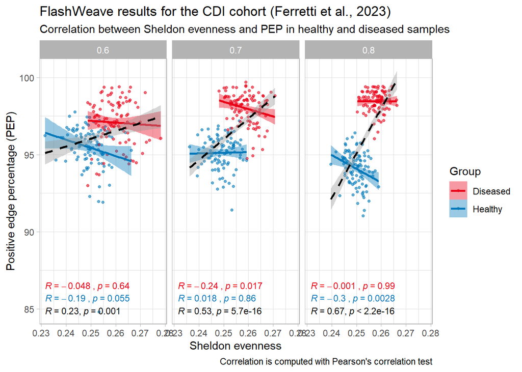

```r
df_res |>
  ggplot() +
  aes(x = sheldon, y = pep, color = group, fill = group) +
  geom_point(alpha = 0.6, size = 1) +
  geom_smooth(method = "lm", se = TRUE) +
  geom_smooth(aes(x = sheldon, y = pep), method = "lm",
              se = TRUE, inherit.aes = FALSE,
              color = "black", linetype = "dashed") +
  ggpubr::stat_cor(aes(label = after_stat(paste(r.label, p.label, sep = "~`,`~"))),
                   method = "pearson", label.x.npc = "left", label.y.npc = 0.12,
                   size = 3, show.legend = FALSE) +
  ggpubr::stat_cor(aes(x = sheldon, y = pep), method = "pearson",
                   inherit.aes = FALSE, color = "black",
                   label.x.npc = "left", label.y.npc = 0.010,
                   size = 3) +
  scale_color_manual(values = c("Healthy" = "#0078B9", "Diseased" = "#EA0017")) +
  scale_fill_manual(values  = c("Healthy" = "#0078B9", "Diseased" = "#EA0017")) +
  facet_wrap(~ fraction) +
  labs(x = "Sheldon evenness", y = "Positive edge percentage (PEP)", color = "Group", fill = "Group", title = "FlashWeave results for the CDI cohort (Ferretti et al., 2023)", subtitle = "Correlation between Sheldon evenness and PEP in healthy and diseased samples", caption = "Correlation is computed with Pearson's correlation test")
```

There is indeed a **significant positive correlation between Sheldon evenness and PEP**, meaning that samples with higher evenness tend to have a higher PEP.

We also compute the net interactions (rho) in the healthy and diseased samples and compare it with PEP in the plot below.

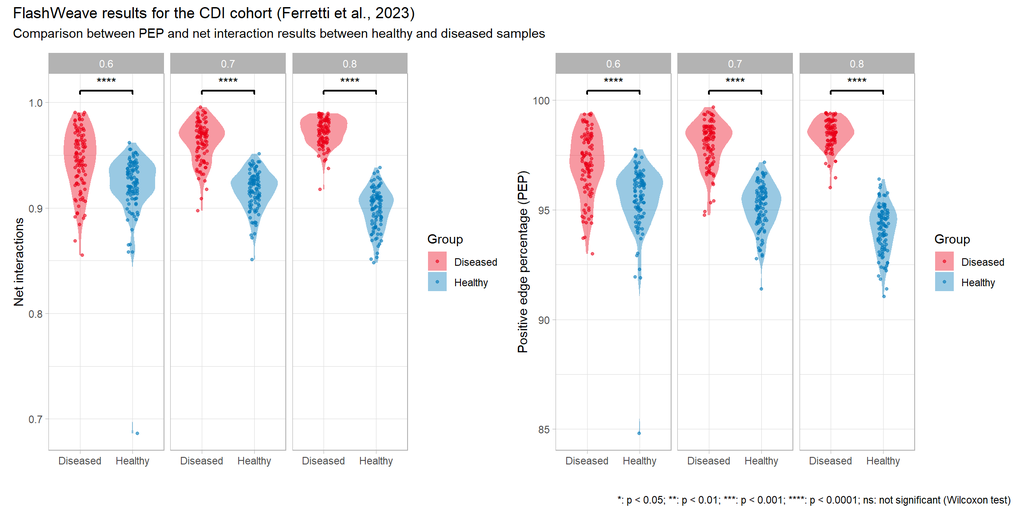

```r
df_res |>
  ggplot() +
  aes(x = group, y = rho, color = group, fill = group) +
  geom_violin(alpha = 0.4, color = NA) +
  geom_point(position = position_jitter(width = 0.1), alpha = 0.6, size = 1) +
  scale_color_manual(values = c("Healthy" = "#0078B9", "Diseased" = "#EA0017")) +
  scale_fill_manual(values  = c("Healthy" = "#0078B9", "Diseased" = "#EA0017")) +
  facet_wrap(~ fraction) +
  labs(x = "", y = "Net interactions", color = "Group", fill = "Group") +
  stat_compare_means(
    comparisons = list(c("Healthy", "Diseased")),
    method = "wilcox.test",
    label = "p.signif",
    tip.length = 0.01,
    bracket.size = 0.8,
    fontface = "bold"
  ) +

df_res |>
  ggplot() +
  aes(x = group, y = pep, color = group, fill = group) +
  geom_violin(alpha = 0.4, color = NA) +
  geom_point(position = position_jitter(width = 0.1), alpha = 0.6, size = 1) +
  scale_color_manual(values = c("Healthy" = "#0078B9", "Diseased" = "#EA0017")) +
  scale_fill_manual(values  = c("Healthy" = "#0078B9", "Diseased" = "#EA0017")) +
  facet_wrap(~ fraction) +
  labs(x = "", y = "Positive edge percentage (PEP)", color = "Group", fill = "Group") +
  stat_compare_means(
    comparisons = list(c("Healthy", "Diseased")),
    method = "wilcox.test",
    label = "p.signif",
    tip.length = 0.01,
    bracket.size = 0.8,
    fontface = "bold"
  ) +

plot_layout(nrow = 1) + plot_annotation(title = "FlashWeave results for the CDI cohort (Ferretti et al., 2023)", subtitle = "Comparison between PEP and net interaction results between healthy and diseased samples", caption = "*: p < 0.05; **: p < 0.01; ***: p < 0.001; ****: p < 0.0001; ns: not significant (Wilcoxon test)")
```

Contrary to the IBD cohort, net interactions (rho) and PEP results are consistent in the CDI cohort, with **diseased samples having a higher PEP and a higher net interaction compared to healthy samples**.

We check correlation between net interaction and Sheldon evenness in the plot below.

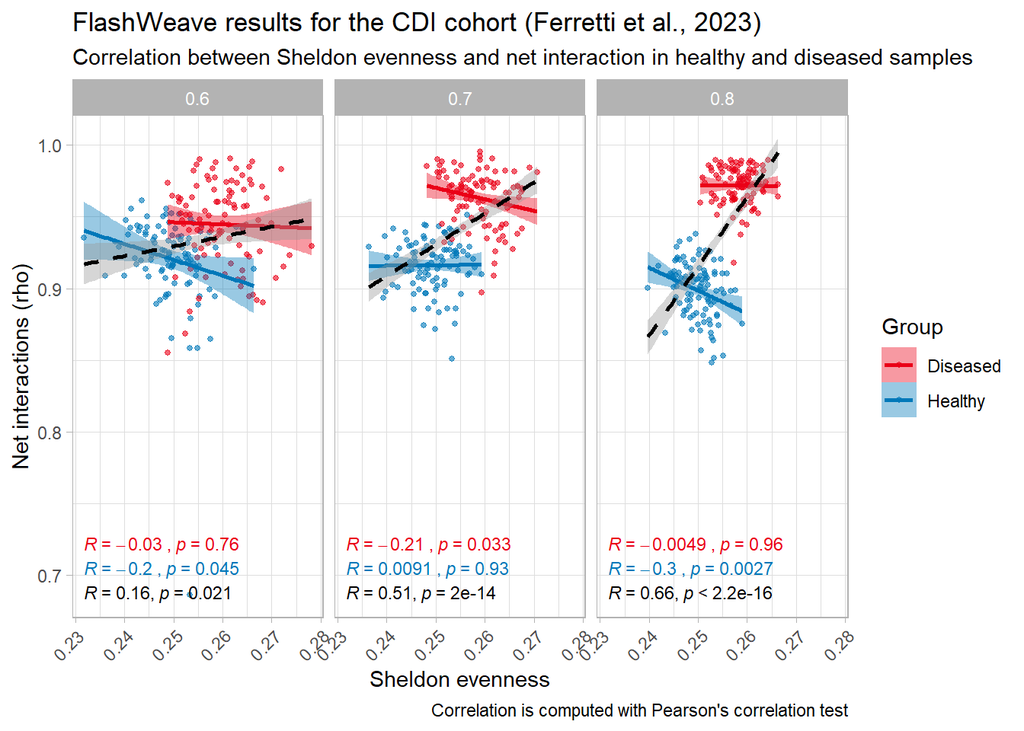

```r
df_res |>
  ggplot() +
  aes(x = sheldon, y = rho, color = group, fill = group) +
  geom_point(alpha = 0.6, size = 1) +
  geom_smooth(method = "lm", se = TRUE) +
  geom_smooth(aes(x = sheldon, y = rho), method = "lm",
              se = TRUE, inherit.aes = FALSE,
              color = "black", linetype = "dashed") +
  ggpubr::stat_cor(aes(label = after_stat(paste(r.label, p.label, sep = "~`,`~"))),
                   method = "pearson", label.x.npc = "left", label.y.npc = 0.12,
                   size = 3, show.legend = FALSE) +
  ggpubr::stat_cor(aes(x = sheldon, y = rho), method = "pearson",
                   inherit.aes = FALSE, color = "black",
                   label.x.npc = "left", label.y.npc = 0.01,
                   size = 3) +
  scale_color_manual(values = c("Healthy" = "#0078B9", "Diseased" = "#EA0017")) +
  scale_fill_manual(values  = c("Healthy" = "#0078B9", "Diseased" = "#EA0017")) +
  facet_wrap(~ fraction) +
  labs(x = "Sheldon evenness", y = "Net interactions (rho)", color = "Group", fill = "Group", title = "FlashWeave results for the CDI cohort (Ferretti et al., 2023)", subtitle = "Correlation between Sheldon evenness and net interaction in healthy and diseased samples", caption = "Correlation is computed with Pearson's correlation test") +
  theme(axis.text.x = element_text(angle = 45, hjust = 1))
```

Similar to PEP, there is a **significant positive correlation between Sheldon evenness and net interactions** (rho), meaning that samples with higher evenness tend to have a higher net interaction.

We will now perform the network analysis on top taxa selected based on their relative abundance. We select a data-driven threshold for relative abundance, which is shown in the plot below. We will keep taxa with a mean relative abundance of at least 0.001 (that is, log10 mean relative abundance of -3). This threshold correspond to the moment when the count starts to drop. Taxa with a mean relative abundance below this threshold will be grouped in a category named “Other”. This is done in the chunk code below.

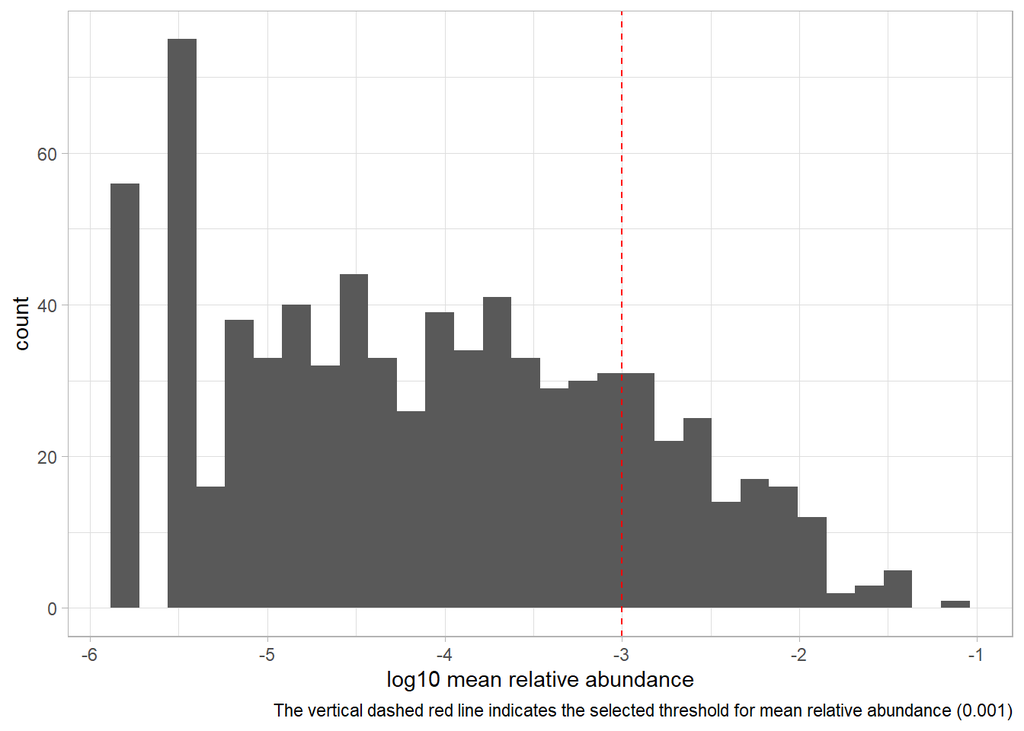

```r
# find data-driven threshold for relative abundance

tmp |>
  group_by(taxon) |>
  summarise(mean_rel_ab = mean(rel_ab)) |>
  arrange(desc(mean_rel_ab)) |>
  ggplot() +
  aes(x = mean_rel_ab |> log10()) +
  geom_histogram(bins = 30) +
  geom_vline(xintercept = -3, linetype = "dashed", color = "red") +
  labs(x = "log10 mean relative abundance", y = "count", caption = "The vertical dashed red line indicates the selected threshold for mean relative abundance (0.001)")
```

```r
# filter taxa based on mean relative abundance

tmp_filtered_healthy_top <-
  filter_abundance(tmp_healthy, abundance_threshold = 0.001) |>
  left_join(
    mae[["CDI"]] |> colData() |> as_tibble(rownames = "uid") |> select(uid, status, subject_disease_status),
    by = join_by(uid)
  )
```

```
Keeping 129 out of 878 taxa with mean abundance >= 0.001
```

```r
tmp_filtered_diseased_top <-
  filter_abundance(tmp_diseased, abundance_threshold = 0.001) |>
  left_join(
    mae[["CDI"]] |> colData() |> as_tibble(rownames = "uid") |> select(uid, status, subject_disease_status),
    by = join_by(uid)
  )
```

```
Keeping 136 out of 878 taxa with mean abundance >= 0.001
```

```r
healthy_df_top <-
  tmp_filtered_healthy_top |>
  select(uid, taxon, rel_ab) |>
  pivot_wider(names_from = taxon, values_from = rel_ab) |>
  column_to_rownames("uid") |>
  t()

diseased_df_top <-
  tmp_filtered_diseased_top |>
  select(uid, taxon, rel_ab) |>
  pivot_wider(names_from = taxon, values_from = rel_ab) |>
  column_to_rownames("uid") |>
  t()
```

```r
# res_healthy_top <- run_network_bootstrap(healthy_df_top, run_fn = run_flashweave, n_bootstrap = 100, subsample_pcts = c(0.6, 0.7, 0.8), max_attempts = 120, prevalence_threshold = 0)
# res_diseased_top <- run_network_bootstrap(diseased_df_top, run_fn = run_flashweave, n_bootstrap = 100, subsample_pcts = c(0.6, 0.7, 0.8), max_attempts = 120, prevalence_threshold = 0)
#
# saveRDS(res_healthy_top, file = str_c(result_dir(), "/flashweave_res_healthy_CDI_top_20260328.rds"))
# saveRDS(res_diseased_top, file = str_c(result_dir(), "/flashweave_res_diseased_CDI_top_20260328.rds"))
```

```r
res_healthy_top <- readRDS(file = str_c(result_dir(), "/flashweave_res_healthy_CDI_top_20260328.rds"))
res_diseased_top <- readRDS(file = str_c(result_dir(), "/flashweave_res_diseased_CDI_top_20260328.rds"))

df_res_healthy_top <- get_stats_df(res_healthy_top, symmetric = TRUE)
df_res_diseased_top <- get_stats_df(res_diseased_top, symmetric = TRUE)

df_res_top <-
  bind_rows(
    df_res_healthy_top |> mutate(group = "Healthy"),
    df_res_diseased_top |> mutate(group = "Diseased")
  )
```

We plot the results below.

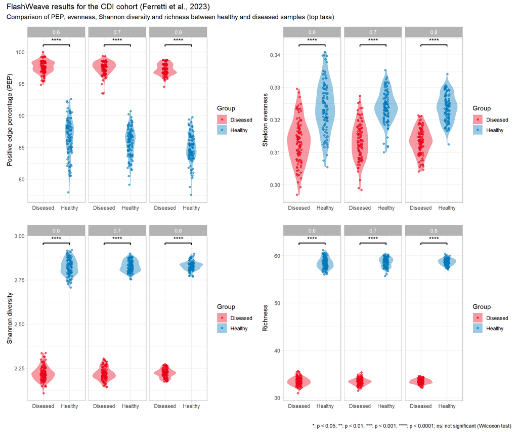

```r
# PEP plot

df_res_top |>
  ggplot() +
  aes(x = group, y = pep, color = group, fill = group) +
  geom_violin(alpha = 0.4, color = NA) +
  geom_point(position = position_jitter(width = 0.1), alpha = 0.6) +
  scale_color_manual(values = c("Healthy" = "#0078B9", "Diseased" = "#EA0017")) +
  scale_fill_manual(values  = c("Healthy" = "#0078B9", "Diseased" = "#EA0017")) +
  facet_wrap(~ fraction) +
  labs(x = "", y = "Positive edge percentage (PEP)", color = "Group", fill = "Group") +
  stat_compare_means(
    comparisons = list(c("Healthy", "Diseased")),
    method = "wilcox.test",
    label = "p.signif",
    tip.length = 0.01,
    bracket.size = 0.8,
    fontface = "bold"
  ) +

df_res_top |>
  ggplot() +
  aes(x = group, y = sheldon, color = group, fill = group) +
  geom_violin(alpha = 0.4, color = NA) +
  geom_point(position = position_jitter(width = 0.1), alpha = 0.6) +
  scale_color_manual(values = c("Healthy" = "#0078B9", "Diseased" = "#EA0017")) +
  scale_fill_manual(values  = c("Healthy" = "#0078B9", "Diseased" = "#EA0017")) +
  facet_wrap(~ fraction) +
  labs(x = "", y = "Sheldon evenness", color = "Group", fill = "Group") +
  stat_compare_means(
    comparisons = list(c("Healthy", "Diseased")),
    method = "wilcox.test",
    label = "p.signif",
    tip.length = 0.01,
    bracket.size = 0.8,
    fontface = "bold"
  ) +

df_res_top |>
  ggplot() +
  aes(x = group, y = shannon, color = group, fill = group) +
  geom_violin(alpha = 0.4, color = NA) +
  geom_point(position = position_jitter(width = 0.1), alpha = 0.6) +
  scale_color_manual(values = c("Healthy" = "#0078B9", "Diseased" = "#EA0017")) +
  scale_fill_manual(values  = c("Healthy" = "#0078B9", "Diseased" = "#EA0017")) +
  facet_wrap(~ fraction) +
  labs(x = "", y = "Shannon diversity", color = "Group", fill = "Group") +
  stat_compare_means(
    comparisons = list(c("Healthy", "Diseased")),
    method = "wilcox.test",
    label = "p.signif",
    tip.length = 0.01,
     bracket.size = 0.8,
    fontface = "bold"
  ) +

df_res_top |>
  ggplot() +
  aes(x = group, y = richness, color = group, fill = group) +
  geom_violin(alpha = 0.4, color = NA) +
  geom_point(position = position_jitter(width = 0.1), alpha = 0.6) +
  scale_color_manual(values = c("Healthy" = "#0078B9", "Diseased" = "#EA0017")) +
  scale_fill_manual(values  = c("Healthy" = "#0078B9", "Diseased" = "#EA0017")) +
  facet_wrap(~ fraction) +
  labs(x = "", y = "Richness", color = "Group", fill = "Group") +
  stat_compare_means(
    comparisons = list(c("Healthy", "Diseased")),
    method = "wilcox.test",
    label = "p.signif",
    tip.length = 0.01,
    bracket.size = 0.8,
    fontface = "bold"
  ) +

  patchwork::plot_layout(nrow = 2) + patchwork::plot_annotation(title = "FlashWeave results for the CDI cohort (Ferretti et al., 2023)", subtitle = "Comparison of PEP, evenness, Shannon diversity and richness between healthy and diseased samples (top taxa)", caption = "*: p < 0.05; **: p < 0.01; ***: p < 0.001; ****: p < 0.0001; ns: not significant (Wilcoxon test)")
```

In the plots above, we can see that **PEP is higher in the diseased samples compared to the healthy samples**. We also observe higher evenness, Shannon diversity and richness in healthy samples compared to diseased samples. Interestingly, **Sheldon evenness is now lower in diseased samples compared to healthy samples**, which is consistent with the expected results for CDI, but different from the results obtained when running FlashWeave on all taxa.

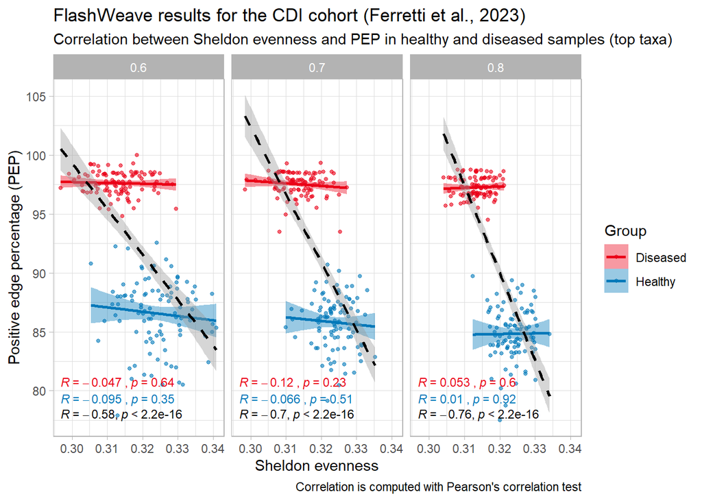

```r
df_res_top |>
  ggplot() +
  aes(x = sheldon, y = pep, color = group, fill = group) +
  geom_point(alpha = 0.6, size = 1) +
  geom_smooth(method = "lm", se = TRUE) +
  geom_smooth(aes(x = sheldon, y = pep), method = "lm",
              se = TRUE, inherit.aes = FALSE,
              color = "black", linetype = "dashed") +
  ggpubr::stat_cor(aes(label = after_stat(paste(r.label, p.label, sep = "~`,`~"))),
                   method = "pearson", label.x.npc = "left", label.y.npc = 0.15,
                   size = 3, show.legend = FALSE) +
  ggpubr::stat_cor(aes(x = sheldon, y = pep), method = "pearson",
                   inherit.aes = FALSE, color = "black",
                   label.x.npc = "left", label.y.npc = 0.03,
                   size = 3) +
  scale_color_manual(values = c("Healthy" = "#0078B9", "Diseased" = "#EA0017")) +
  scale_fill_manual(values  = c("Healthy" = "#0078B9", "Diseased" = "#EA0017")) +
  facet_wrap(~ fraction) +
  labs(x = "Sheldon evenness", y = "Positive edge percentage (PEP)", color = "Group", fill = "Group", title = "FlashWeave results for the CDI cohort (Ferretti et al., 2023)", subtitle = "Correlation between Sheldon evenness and PEP in healthy and diseased samples (top taxa)", caption = "Correlation is computed with Pearson's correlation test")
```

We can see that there is a **negative correlation between Sheldon evenness and PEP**, meaning that samples with higher evenness tend to have a lower PEP, which is not consistent with the results obtained when running FlashWeave on all taxa, where we observed a positive correlation between Sheldon evenness and PEP.

We also compute below the net interactions (rho) in the healthy and diseased samples in the plot below and compare it with PEP.

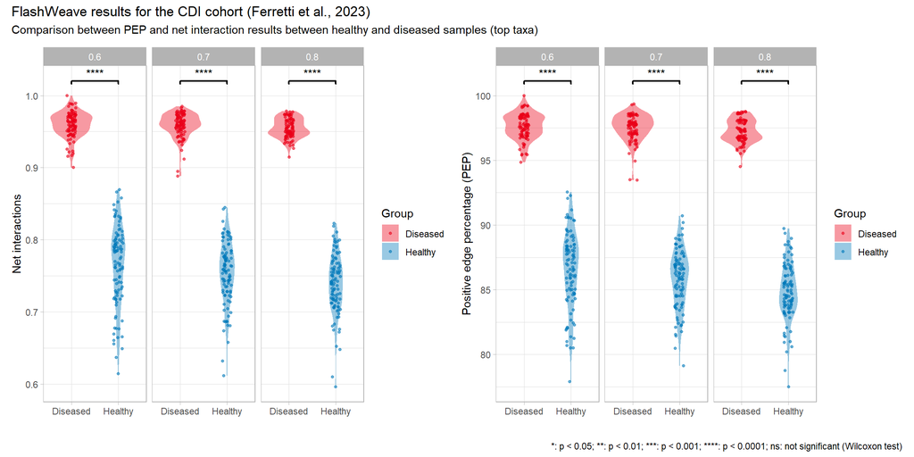

```r
df_res_top |>
  ggplot() +
  aes(x = group, y = rho, color = group, fill = group) +
  geom_violin(alpha = 0.4, color = NA) +
  geom_point(position = position_jitter(width = 0.1), alpha = 0.6, size = 1) +
  scale_color_manual(values = c("Healthy" = "#0078B9", "Diseased" = "#EA0017")) +
  scale_fill_manual(values  = c("Healthy" = "#0078B9", "Diseased" = "#EA0017")) +
  facet_wrap(~ fraction) +
  labs(x = "", y = "Net interactions", color = "Group", fill = "Group") +
  stat_compare_means(
    comparisons = list(c("Healthy", "Diseased")),
    method = "wilcox.test",
    label = "p.signif",
    tip.length = 0.01,
    bracket.size = 0.8,
    fontface = "bold"
  ) +

df_res_top |>
  ggplot() +
  aes(x = group, y = pep, color = group, fill = group) +
  geom_violin(alpha = 0.4, color = NA) +
  geom_point(position = position_jitter(width = 0.1), alpha = 0.6, size = 1) +
  scale_color_manual(values = c("Healthy" = "#0078B9", "Diseased" = "#EA0017")) +
  scale_fill_manual(values  = c("Healthy" = "#0078B9", "Diseased" = "#EA0017")) +
  facet_wrap(~ fraction) +
  labs(x = "", y = "Positive edge percentage (PEP)", color = "Group", fill = "Group") +
  stat_compare_means(
    comparisons = list(c("Healthy", "Diseased")),
    method = "wilcox.test",
    label = "p.signif",
    tip.length = 0.01,
    bracket.size = 0.8,
    fontface = "bold"
  ) +

plot_layout(nrow = 1) + plot_annotation(title = "FlashWeave results for the CDI cohort (Ferretti et al., 2023)", subtitle = "Comparison between PEP and net interaction results between healthy and diseased samples (top taxa)", caption = "*: p < 0.05; **: p < 0.01; ***: p < 0.001; ****: p < 0.0001; ns: not significant (Wilcoxon test)")
```

Again, we see that net interactions (rho) and PEP results are consistent in the CDI cohort, with **diseased samples having a higher PEP and a higher net interaction compared to healthy samples**, and the trend is more exacerbated when running FlashWeave on top taxa compared to running it on all taxa.

We check correlation between net interaction and Sheldon evenness in the plot below.

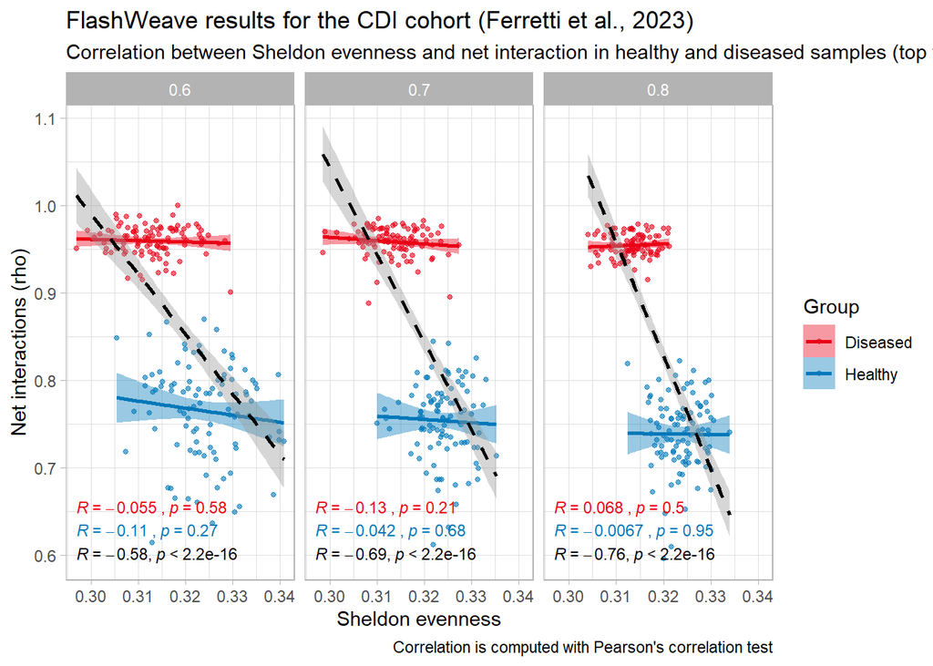

```r
df_res_top |>
  ggplot() +
  aes(x = sheldon, y = rho, color = group, fill = group) +
  geom_point(alpha = 0.6, size = 1) +
  geom_smooth(method = "lm", se = TRUE) +
  geom_smooth(aes(x = sheldon, y = rho), method = "lm",
              se = TRUE, inherit.aes = FALSE,
              color = "black", linetype = "dashed") +
  ggpubr::stat_cor(aes(label = after_stat(paste(r.label, p.label, sep = "~`,`~"))),
                   method = "pearson", label.x.npc = "left", label.y.npc = 0.15,
                   size = 3, show.legend = FALSE) +
  ggpubr::stat_cor(aes(x = sheldon, y = rho), method = "pearson",
                   inherit.aes = FALSE, color = "black",
                   label.x.npc = "left", label.y.npc = 0.02,
                   size = 3) +
  scale_color_manual(values = c("Healthy" = "#0078B9", "Diseased" = "#EA0017")) +
  scale_fill_manual(values  = c("Healthy" = "#0078B9", "Diseased" = "#EA0017")) +
  facet_wrap(~ fraction) +
  labs(x = "Sheldon evenness", y = "Net interactions (rho)", color = "Group", fill = "Group",
       title = "FlashWeave results for the CDI cohort (Ferretti et al., 2023)",
       subtitle = "Correlation between Sheldon evenness and net interaction in healthy and diseased samples (top taxa)",
       caption = "Correlation is computed with Pearson's correlation test")
```

There is a significant negative correlation between Sheldon evenness and net interactions (rho), meaning that samples with higher evenness tend to have a lower net interaction.

## CRC cohort (Yachida et al., 2019)

We import the CRC dataset from the MAE object in the chunk code below.

```r
tmp <-
  mae[["CRC"]] |>
  assay() |>
  t() |>
  as.data.frame() |>
  rownames_to_column("uid") |>
  pivot_longer(-uid, names_to = "taxon", values_to = "count") |>
  group_by(uid) |>
  mutate(rel_ab = count/sum(count)) |>
  left_join(
    mae[["CRC"]] |> colData() |> as_tibble(rownames = "uid") |> select(uid, cohort),
    by = join_by(uid)
  )
```

We separate healthy and diseased samples and prepare the dataframes for FlashWeave in the chunk code below.

```r
tmp_healthy <- tmp |> filter(cohort == "H")
tmp_diseased <- tmp |> filter(cohort == "CRC")

# for healthy samples

healthy_df <-
  tmp_healthy |>
  select(uid, taxon, rel_ab) |>
  pivot_wider(names_from = taxon, values_from = rel_ab) |>
  column_to_rownames("uid") |>
  t()

# for diseased samples

diseased_df <-
  tmp_diseased |>
  select(uid, taxon, rel_ab) |>
  pivot_wider(names_from = taxon, values_from = rel_ab) |>
  column_to_rownames("uid") |>
  t()
```

### Running Flashweave on all taxa

In the chunk code below, we run FlashWeave on all taxa for healthy and diseased samples separately, with the following parameters: `n_bootstrap = 100`, `subsample_pcts = c(0.6, 0.7, 0.8)`, `max_attempts = 120`, and `prevalence_threshold = 0.05`. This means that in each bootstrap iteration, we will subsample the data at different percentages (60%, 70%, and 80%) and run FlashWeave on the subsampled data. The `prevalence_threshold` parameter is set to 0.05, meaning that taxa that are present in less than 5% of the samples will be filtered out before running FlashWeave.

```r
# res_healthy <- run_network_bootstrap(healthy_df, run_fn = run_flashweave, n_bootstrap = 100, subsample_pcts = c(0.6, 0.7, 0.8), max_attempts = 120, prevalence_threshold = 0.05)
# res_diseased <- run_network_bootstrap(diseased_df, run_fn = run_flashweave, n_bootstrap = 100, subsample_pcts = c(0.6, 0.7, 0.8), max_attempts = 120, prevalence_threshold = 0.05)

# saveRDS(res_healthy, file = str_c(result_dir(), "/flashweave_res_healthy_CRC_20260328.rds"))
# saveRDS(res_diseased, file = str_c(result_dir(), "/flashweave_res_diseased_CRC_20260328.rds"))
```

We load the results in the chunk code below.

```r
res_healthy <- readRDS(file = str_c(result_dir(), "/flashweave_res_healthy_CRC_20260328.rds"))
res_diseased <- readRDS(file = str_c(result_dir(), "/flashweave_res_diseased_CRC_20260328.rds"))
```

```r
df_res_healthy <- get_stats_df(res_healthy, symmetric = TRUE)
df_res_diseased <- get_stats_df(res_diseased, symmetric = TRUE)

df_res <-
  bind_rows(
    df_res_healthy |> mutate(group = "Healthy"),
    df_res_diseased |> mutate(group = "Diseased")
  )
```

We plot the results below.

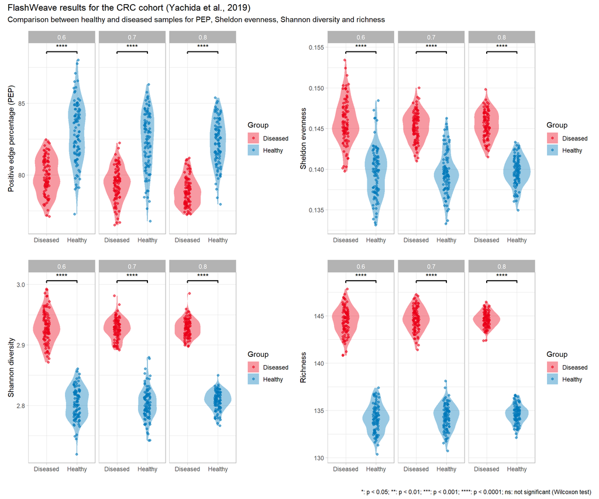

```r
df_res |>
  ggplot() +
  aes(x = group, y = pep, color = group, fill = group) +
  geom_violin(alpha = 0.4, color = NA) +
  geom_point(position = position_jitter(width = 0.1), alpha = 0.6) +
  scale_color_manual(values = c("Healthy" = "#0078B9", "Diseased" = "#EA0017")) +
  scale_fill_manual(values  = c("Healthy" = "#0078B9", "Diseased" = "#EA0017")) +
  facet_wrap(~ fraction) +
  labs(x = "", y = "Positive edge percentage (PEP)", color = "Group", fill = "Group") +
  stat_compare_means(
    comparisons = list(c("Healthy", "Diseased")),
    method = "wilcox.test",
    label = "p.signif",
    tip.length = 0.01,
    bracket.size = 0.8,
    fontface = "bold"
  ) +
df_res |>
  ggplot() +
  aes(x = group, y = sheldon, color = group, fill = group) +
  geom_violin(alpha = 0.4, color = NA) +
  geom_point(position = position_jitter(width = 0.1), alpha = 0.6) +
  scale_color_manual(values = c("Healthy" = "#0078B9", "Diseased" = "#EA0017")) +
  scale_fill_manual(values  = c("Healthy" = "#0078B9", "Diseased" = "#EA0017")) +
  facet_wrap(~ fraction) +
  labs(x = "", y = "Sheldon evenness", color = "Group", fill = "Group") +
  stat_compare_means(
    comparisons = list(c("Healthy", "Diseased")),
    method = "wilcox.test",
    label = "p.signif",
    tip.length = 0.01,
    bracket.size = 0.8,
    fontface = "bold"
  ) +

# shannon diversity
df_res |>
  ggplot() +
  aes(x = group, y = shannon, color = group, fill = group) +
  geom_violin(alpha = 0.4, color = NA) +
  geom_point(position = position_jitter(width = 0.1), alpha = 0.6) +
  scale_color_manual(values = c("Healthy" = "#0078B9", "Diseased" = "#EA0017")) +
  scale_fill_manual(values  = c("Healthy" = "#0078B9", "Diseased" = "#EA0017")) +
  facet_wrap(~ fraction) +
  labs(x = "", y = "Shannon diversity", color = "Group", fill = "Group") +
  stat_compare_means(
    comparisons = list(c("Healthy", "Diseased")),
    method = "wilcox.test",
    label = "p.signif",
    tip.length = 0.01,
    bracket.size = 0.8,
    fontface = "bold"
  ) +

# richness
df_res |>
  ggplot() +
  aes(x = group, y = richness, color = group, fill = group) +
  geom_violin(alpha = 0.4, color = NA) +
  geom_point(position = position_jitter(width = 0.1), alpha = 0.6) +
  scale_color_manual(values = c("Healthy" = "#0078B9", "Diseased" = "#EA0017")) +
  scale_fill_manual(values  = c("Healthy" = "#0078B9", "Diseased" = "#EA0017")) +
  facet_wrap(~ fraction) +
  labs(x = "", y = "Richness", color = "Group", fill = "Group") +
  stat_compare_means(
    comparisons = list(c("Healthy", "Diseased")),
    method = "wilcox.test",
    label = "p.signif",
    tip.length = 0.01,
    bracket.size = 0.8,
    fontface = "bold"
  ) +

  patchwork::plot_layout(nrow = 2) + plot_annotation(title = "FlashWeave results for the CRC cohort (Yachida et al., 2019)", subtitle = "Comparison between healthy and diseased samples for PEP, Sheldon evenness, Shannon diversity and richness", caption = "*: p < 0.05; **: p < 0.01; ***: p < 0.001; ****: p < 0.0001; ns: not significant (Wilcoxon test)")
```

In the plots above, we can see that **Sheldon evenness, Shannon diversity and richness are higher in the diseased samples compared to the healthy samples**. We did not expect to observe higher evenness in diseased samples compared to healthy samples (check why). Also, we see that PEP is higher in healthy samples compared to diseased samples, which is not consistent with the results obtained in the original article.

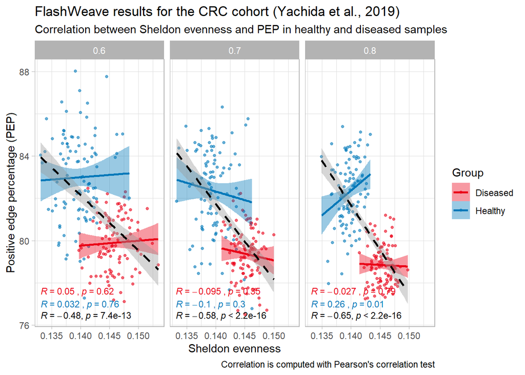

```r
df_res |>
  ggplot() +
  aes(x = sheldon, y = pep, color = group, fill = group) +
  geom_point(alpha = 0.6, size = 1) +
  geom_smooth(method = "lm", se = TRUE) +
  geom_smooth(aes(x = sheldon, y = pep), method = "lm",
              se = TRUE, inherit.aes = FALSE,
              color = "black", linetype = "dashed") +
  ggpubr::stat_cor(aes(label = after_stat(paste(r.label, p.label, sep = "~`,`~"))),
                   method = "pearson", label.x.npc = "left", label.y.npc = 0.10,
                   size = 3, show.legend = FALSE) +
  ggpubr::stat_cor(aes(x = sheldon, y = pep), method = "pearson",
                   inherit.aes = FALSE, color = "black",
                   label.x.npc = "left", label.y.npc = 0.001,
                   size = 3) +
  scale_color_manual(values = c("Healthy" = "#0078B9", "Diseased" = "#EA0017")) +
  scale_fill_manual(values  = c("Healthy" = "#0078B9", "Diseased" = "#EA0017")) +
  facet_wrap(~ fraction) +
  labs(x = "Sheldon evenness", y = "Positive edge percentage (PEP)", color = "Group", fill = "Group", title = "FlashWeave results for the CRC cohort (Yachida et al., 2019)", subtitle = "Correlation between Sheldon evenness and PEP in healthy and diseased samples", caption = "Correlation is computed with Pearson's correlation test")
```

We can see that there is a **negative correlation between Sheldon evenness and PEP**, meaning that samples with higher evenness tend to have a lower PEP.

We also plot the net interactions (rho) in the healthy and diseased samples in the plot below, and compare it with PEP.

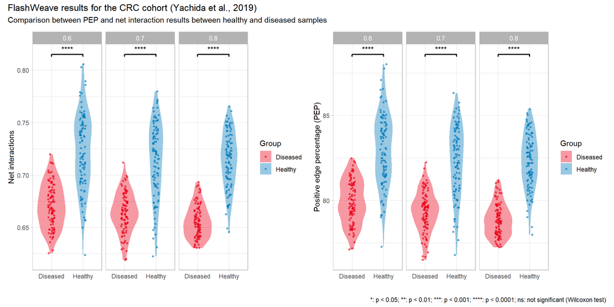

```r
df_res |>
  ggplot() +
  aes(x = group, y = rho, color = group, fill = group) +
  geom_violin(alpha = 0.4, color = NA) +
  geom_point(position = position_jitter(width = 0.1), alpha = 0.6, size = 1) +
  scale_color_manual(values = c("Healthy" = "#0078B9", "Diseased" = "#EA0017")) +
  scale_fill_manual(values  = c("Healthy" = "#0078B9", "Diseased" = "#EA0017")) +
  facet_wrap(~ fraction) +
  labs(x = "", y = "Net interactions", color = "Group", fill = "Group") +
  stat_compare_means(
    comparisons = list(c("Healthy", "Diseased")),
    method = "wilcox.test",
    label = "p.signif",
    tip.length = 0.01,
    bracket.size = 0.8,
    fontface = "bold"
  ) +

df_res |>
  ggplot() +
  aes(x = group, y = pep, color = group, fill = group) +
  geom_violin(alpha = 0.4, color = NA) +
  geom_point(position = position_jitter(width = 0.1), alpha = 0.6, size = 1) +
  scale_color_manual(values = c("Healthy" = "#0078B9", "Diseased" = "#EA0017")) +
  scale_fill_manual(values  = c("Healthy" = "#0078B9", "Diseased" = "#EA0017")) +
  facet_wrap(~ fraction) +
  labs(x = "", y = "Positive edge percentage (PEP)", color = "Group", fill = "Group") +
  stat_compare_means(
    comparisons = list(c("Healthy", "Diseased")),
    method = "wilcox.test",
    label = "p.signif",
    tip.length = 0.01,
    bracket.size = 0.8,
    fontface = "bold"
  ) +

  patchwork::plot_layout(nrow = 1) + plot_annotation(title = "FlashWeave results for the CRC cohort (Yachida et al., 2019)", subtitle = "Comparison between PEP and net interaction results between healthy and diseased samples", caption = "*: p < 0.05; **: p < 0.01; ***: p < 0.001; ****: p < 0.0001; ns: not significant (Wilcoxon test)")
```

Surprisingly, we see that net interactions (rho) and PEP results are consistent in the CRC cohort, with **healthy samples having a higher PEP and a higher net interaction compared to diseased samples**, which is not consistent with the results obtained in the original article, but consistent with the results obtained when running FlashWeave on top taxa, where we observed a higher PEP and a higher net interaction in healthy samples compared to diseased samples.

We also check correlation between net interaction and Sheldon evenness in the plot below.

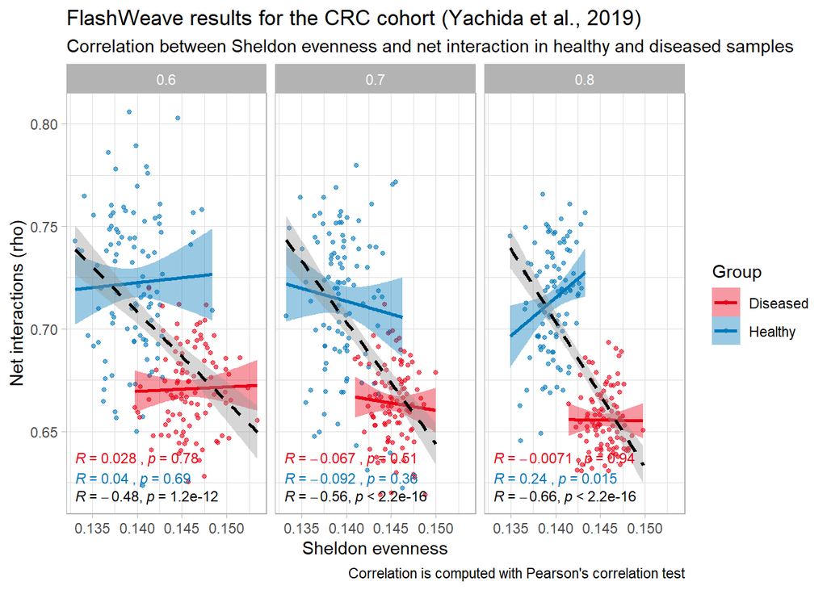

```r
df_res |>
  ggplot() +
  aes(x = sheldon, y = rho, color = group, fill = group) +
  geom_point(alpha = 0.6, size = 1) +
  geom_smooth(method = "lm", se = TRUE) +
  geom_smooth(aes(x = sheldon, y = rho), method = "lm",
              se = TRUE, inherit.aes = FALSE,
              color = "black", linetype = "dashed") +
  ggpubr::stat_cor(aes(label = after_stat(paste(r.label, p.label, sep = "~`,`~"))),
                   method = "pearson", label.x.npc = "left", label.y.npc = 0.10,
                   size = 3, show.legend = FALSE) +
  ggpubr::stat_cor(aes(x = sheldon, y = rho), method = "pearson",
                   inherit.aes = FALSE, color = "black",
                   label.x.npc = "left", label.y.npc = 0.001,
                   size = 3) +
  scale_color_manual(values = c("Healthy" = "#0078B9", "Diseased" = "#EA0017")) +
  scale_fill_manual(values  = c("Healthy" = "#0078B9", "Diseased" = "#EA0017")) +
  facet_wrap(~ fraction) +
  labs(x = "Sheldon evenness", y = "Net interactions (rho)", color = "Group", fill = "Group",
       title = "FlashWeave results for the CRC cohort (Yachida et al., 2019)",
       subtitle = "Correlation between Sheldon evenness and net interaction in healthy and diseased samples",
       caption = "Correlation is computed with Pearson's correlation test")
```

Here, we can see that there is a **significant negative correlation between Sheldon evenness and net interactions** (rho), meaning that samples with higher evenness tend to have a lower net interaction.

### Running FlashWeave on top taxa

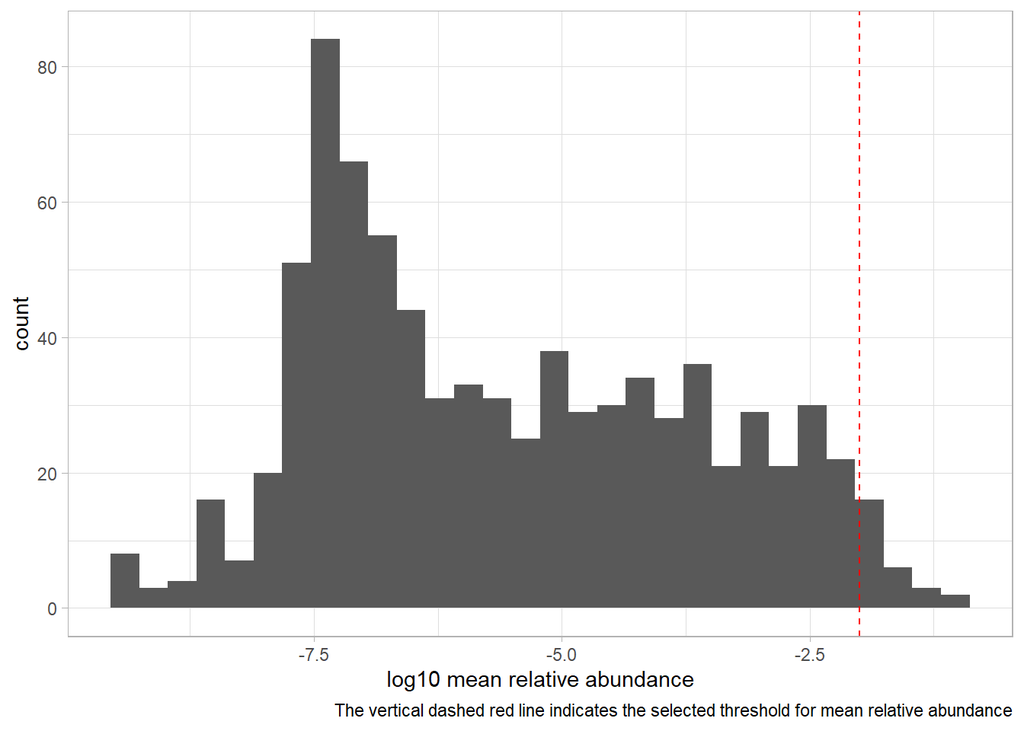

```r
tmp |>
  group_by(taxon) |>
  summarise(mean_rel_ab = mean(rel_ab)) |>
  arrange(desc(mean_rel_ab)) |>
  ggplot() +
  aes(x = mean_rel_ab |> log10()) +
  geom_histogram(bins = 30) +
  geom_vline(xintercept = -2, linetype = "dashed", color = "red") +
  labs(x = "log10 mean relative abundance", y = "count",
       caption = "The vertical dashed red line indicates the selected threshold for mean relative abundance")
```

```r
tmp_filtered_healthy_top <-
  filter_abundance(tmp_healthy, abundance_threshold = 10^-2) |>
  left_join(
    mae[["CRC"]] |> colData() |> as_tibble(rownames = "uid") |> select(uid, cohort),
    by = join_by(uid)
  )
```

```
Keeping 24 out of 837 taxa with mean abundance >= 0.01
```

```r
tmp_filtered_diseased_top <-
  filter_abundance(tmp_diseased, abundance_threshold = 10^-2) |>
  left_join(
    mae[["CRC"]] |> colData() |> as_tibble(rownames = "uid") |> select(uid, cohort),
    by = join_by(uid)
  )
```

```
Keeping 24 out of 837 taxa with mean abundance >= 0.01
```

```r
healthy_df_top <-
  tmp_filtered_healthy_top |>
  select(uid, taxon, rel_ab) |>
  pivot_wider(names_from = taxon, values_from = rel_ab) |>
  column_to_rownames("uid") |>
  t()

diseased_df_top <-
  tmp_filtered_diseased_top |>
  select(uid, taxon, rel_ab) |>
  pivot_wider(names_from = taxon, values_from = rel_ab) |>
  column_to_rownames("uid") |>
  t()
```

```r
# res_healthy_top <- run_network_bootstrap(healthy_df_top, run_fn = run_flashweave, n_bootstrap = 100, subsample_pcts = c(0.6, 0.7, 0.8), max_attempts = 120, prevalence_threshold = 0)
# res_diseased_top <- run_network_bootstrap(diseased_df_top, run_fn = run_flashweave, n_bootstrap = 100, subsample_pcts = c(0.6, 0.7, 0.8), max_attempts = 120, prevalence_threshold = 0)
#
# saveRDS(res_healthy_top, file = str_c(result_dir(), "/flashweave_res_healthy_CRC_top_20260328.rds"))
# saveRDS(res_diseased_top, file = str_c(result_dir(), "/flashweave_res_diseased_CRC_top_20260328.rds"))
```

```r
res_healthy_top <- readRDS(file = str_c(result_dir(), "/flashweave_res_healthy_CRC_top_20260328.rds"))
res_diseased_top <- readRDS(file = str_c(result_dir(), "/flashweave_res_diseased_CRC_top_20260328.rds"))
```

```r
df_res_healthy_top <- get_stats_df(res_healthy_top, symmetric = TRUE)
df_res_diseased_top <- get_stats_df(res_diseased_top, symmetric = TRUE)

df_res_top <-
  bind_rows(
    df_res_healthy_top |> mutate(group = "Healthy"),
    df_res_diseased_top |> mutate(group = "Diseased")
  )
```

We plot the results below.

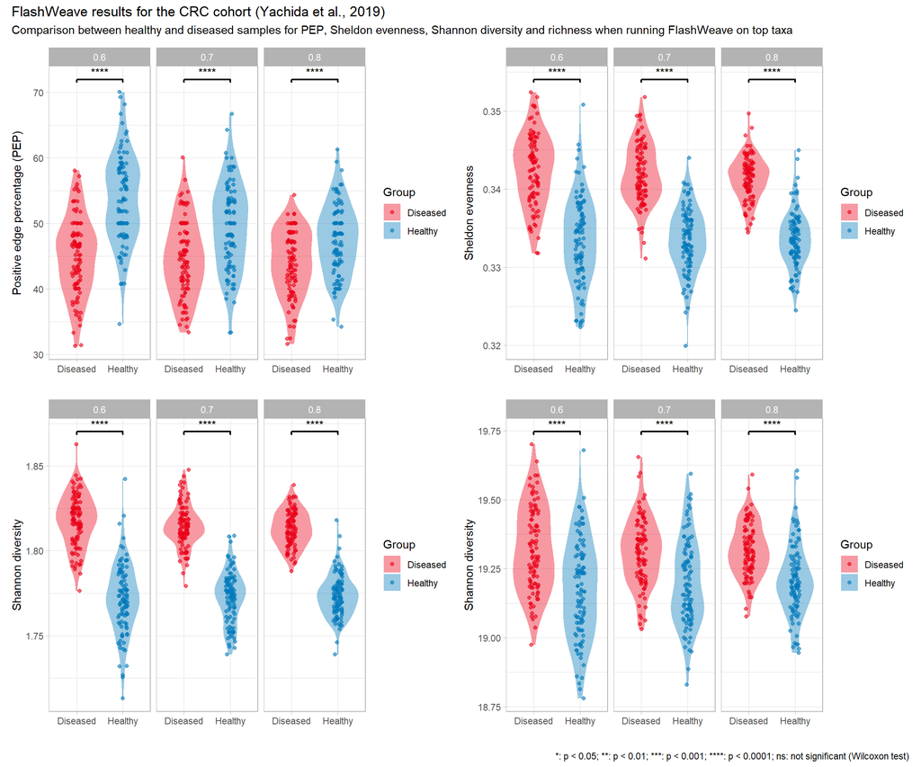

```r
df_res_top |>
  ggplot() +
  aes(x = group, y = pep, color = group, fill = group) +
  geom_violin(alpha = 0.4, color = NA) +
  geom_point(position = position_jitter(width = 0.1), alpha = 0.6) +
  scale_color_manual(values = c("Healthy" = "#0078B9", "Diseased" = "#EA0017")) +
  scale_fill_manual(values  = c("Healthy" = "#0078B9", "Diseased" = "#EA0017")) +
  facet_wrap(~ fraction) +
  labs(x = "", y = "Positive edge percentage (PEP)", color = "Group", fill = "Group") +
  stat_compare_means(
    comparisons = list(c("Healthy", "Diseased")),
    method = "wilcox.test",
    label = "p.signif",
    tip.length = 0.01,
    bracket.size = 0.8,
    fontface = "bold"
  ) +

df_res_top |>
  ggplot() +
  aes(x = group, y = sheldon, color = group, fill = group) +
  geom_violin(alpha = 0.4, color = NA) +
  geom_point(position = position_jitter(width = 0.1), alpha = 0.6) +
  scale_color_manual(values = c("Healthy" = "#0078B9", "Diseased" = "#EA0017")) +
  scale_fill_manual(values  = c("Healthy" = "#0078B9", "Diseased" = "#EA0017")) +
  facet_wrap(~ fraction) +
  labs(x = "", y = "Sheldon evenness", color = "Group", fill = "Group") +
  stat_compare_means(
    comparisons = list(c("Healthy", "Diseased")),
    method = "wilcox.test",
    label = "p.signif",
    tip.length = 0.01,
    bracket.size = 0.8,
    fontface = "bold"
  ) +

# shannon diversity

df_res_top |>
  ggplot() +
  aes(x = group, y = shannon, color = group, fill = group) +
  geom_violin(alpha = 0.4, color = NA) +
  geom_point(position = position_jitter(width = 0.1), alpha = 0.6) +
  scale_color_manual(values = c("Healthy" = "#0078B9", "Diseased" = "#EA0017")) +
  scale_fill_manual(values  = c("Healthy" = "#0078B9", "Diseased" = "#EA0017")) +
  facet_wrap(~ fraction) +
  labs(x = "", y = "Shannon diversity", color = "Group", fill = "Group") +
  stat_compare_means(
    comparisons = list(c("Healthy", "Diseased")),
    method = "wilcox.test",
    label = "p.signif",
    tip.length = 0.01,
    bracket.size = 0.8,
    fontface = "bold"
  ) +

# richness

df_res_top |>
  ggplot() +
  aes(x = group, y = richness, color = group, fill = group) +
  geom_violin(alpha = 0.4, color = NA) +
  geom_point(position = position_jitter(width = 0.1), alpha = 0.6) +
  scale_color_manual(values = c("Healthy" = "#0078B9", "Diseased" = "#EA0017")) +
  scale_fill_manual(values  = c("Healthy" = "#0078B9", "Diseased" = "#EA0017")) +
  facet_wrap(~ fraction) +
  labs(x = "", y = "Shannon diversity", color = "Group", fill = "Group") +
  stat_compare_means(
    comparisons = list(c("Healthy", "Diseased")),
    method = "wilcox.test",
    label = "p.signif",
    tip.length = 0.01,
    bracket.size = 0.8,
    fontface = "bold"
  ) +

  patchwork::plot_layout(nrow = 2) + plot_annotation(title = "FlashWeave results for the CRC cohort (Yachida et al., 2019)", subtitle = "Comparison between healthy and diseased samples for PEP, Sheldon evenness, Shannon diversity and richness when running FlashWeave on top taxa", caption = "*: p < 0.05; **: p < 0.01; ***: p < 0.001; ****: p < 0.0001; ns: not significant (Wilcoxon test)")
```

In the plots above, we can see that **Sheldon evenness, Shannon diversity and richness are higher in the diseased samples compared to the healthy samples**, which is consistent with the results obtained when running FlashWeave on all taxa. Also, we see that **PEP is higher in healthy samples compared to diseased samples**, which is not consistent with the results obtained in the original article, but is consistent with the results obtained when running FlashWeave on all taxa.

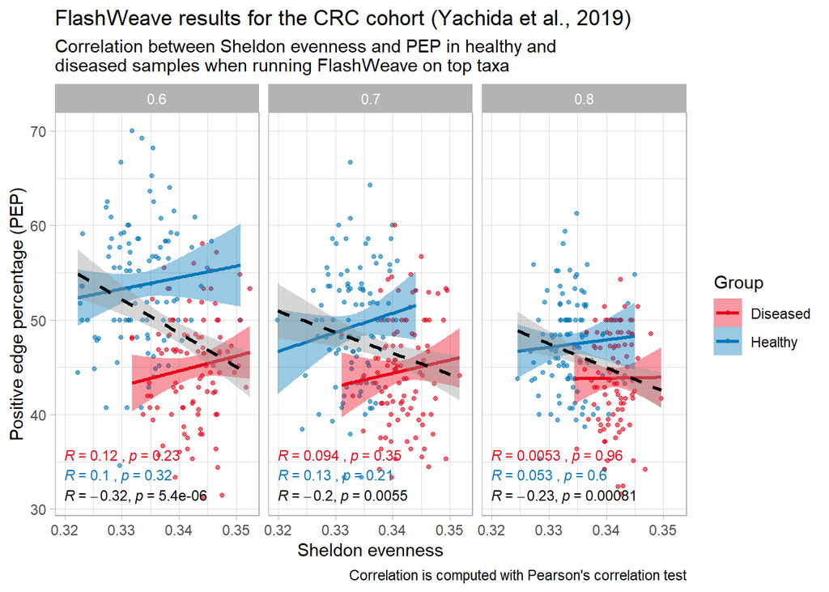

```r
df_res_top |>
  ggplot() +
  aes(x = sheldon, y = pep, color = group, fill = group) +
  geom_point(alpha = 0.6, size = 1) +
  geom_smooth(method = "lm", se = TRUE) +
  geom_smooth(aes(x = sheldon, y = pep), method = "lm",
              se = TRUE, inherit.aes = FALSE,
              color = "black", linetype = "dashed") +
  ggpubr::stat_cor(aes(label = after_stat(paste(r.label, p.label, sep = "~`,`~"))),
                   method = "pearson", label.x.npc = "left", label.y.npc = 0.12,
                   size = 3, show.legend = FALSE) +
  ggpubr::stat_cor(aes(x = sheldon, y = pep), method = "pearson",
                   inherit.aes = FALSE, color = "black",
                   label.x.npc = "left", label.y.npc = 0.01,
                   size = 3) +
  scale_color_manual(values = c("Healthy" = "#0078B9", "Diseased" = "#EA0017")) +
  scale_fill_manual(values  = c("Healthy" = "#0078B9", "Diseased" = "#EA0017")) +
  facet_wrap(~ fraction) +
  labs(x = "Sheldon evenness", y = "Positive edge percentage (PEP)", color = "Group", fill = "Group", title = "FlashWeave results for the CRC cohort (Yachida et al., 2019)", subtitle = "Correlation between Sheldon evenness and PEP in healthy and \ndiseased samples when running FlashWeave on top taxa", caption = "Correlation is computed with Pearson's correlation test")
```

In this plot, we can see that there is a **negative correlation between Sheldon evenness and PEP**, meaning that samples with higher evenness tend to have a lower PEP, which is consistent with the results obtained when running FlashWeave on all taxa.

We also compute below the net interactions (rho) in the healthy and diseased samples in the plot below, and compare it with PEP.

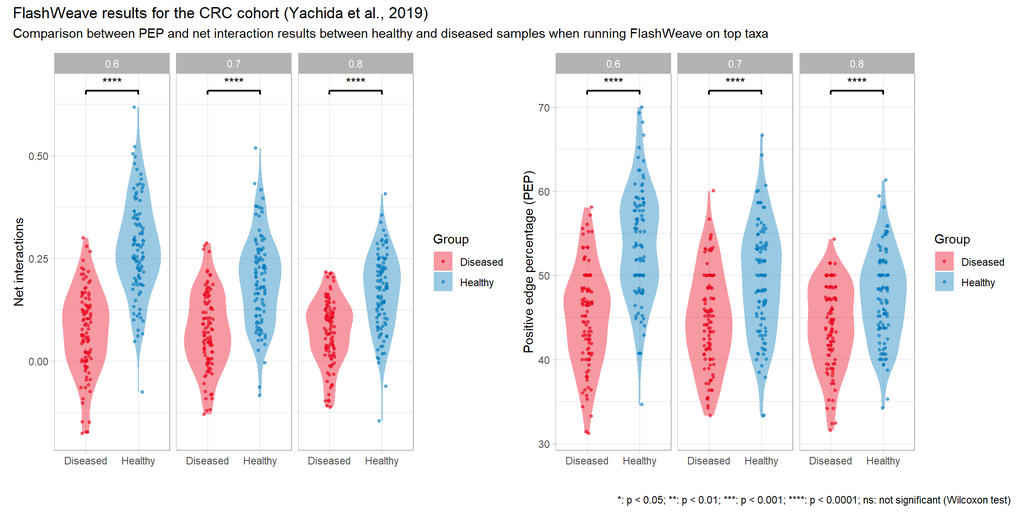

```r
df_res_top |>
  ggplot() +
  aes(x = group, y = rho, color = group, fill = group) +
  geom_violin(alpha = 0.4, color = NA) +
  geom_point(position = position_jitter(width = 0.1), alpha = 0.6, size = 1) +
  scale_color_manual(values = c("Healthy" = "#0078B9", "Diseased" = "#EA0017")) +
  scale_fill_manual(values  = c("Healthy" = "#0078B9", "Diseased" = "#EA0017")) +
  facet_wrap(~ fraction) +
  labs(x = "", y = "Net interactions", color = "Group", fill = "Group") +
  stat_compare_means(
    comparisons = list(c("Healthy", "Diseased")),
    method = "wilcox.test",
    label = "p.signif",
    tip.length = 0.01,
    bracket.size = 0.8,
    fontface = "bold"
  ) +

df_res_top |>
  ggplot() +
  aes(x = group, y = pep, color = group, fill = group) +
  geom_violin(alpha = 0.4, color = NA) +
  geom_point(position = position_jitter(width = 0.1), alpha = 0.6, size = 1) +
  scale_color_manual(values = c("Healthy" = "#0078B9", "Diseased" = "#EA0017")) +
  scale_fill_manual(values  = c("Healthy" = "#0078B9", "Diseased" = "#EA0017")) +
  facet_wrap(~ fraction) +
  labs(x = "", y = "Positive edge percentage (PEP)", color = "Group", fill = "Group") +
  stat_compare_means(
    comparisons = list(c("Healthy", "Diseased")),
    method = "wilcox.test",
    label = "p.signif",
    tip.length = 0.01,
    bracket.size = 0.8,
    fontface = "bold"
  ) +

  patchwork::plot_layout(nrow = 1) + plot_annotation(title = "FlashWeave results for the CRC cohort (Yachida et al., 2019)", subtitle = "Comparison between PEP and net interaction results between healthy and diseased samples when running FlashWeave on top taxa", caption = "*: p < 0.05; **: p < 0.01; ***: p < 0.001; ****: p < 0.0001; ns: not significant (Wilcoxon test)")
```

Similar to results found with all taxa, we see that net interactions (rho) and PEP results are consistent in the CRC cohort when running FlashWeave on top taxa, with **healthy samples having a higher PEP and a higher net interaction compared to diseased samples**, which is not consistent with the results obtained in the original article.

We also check correlation between net interaction and Sheldon evenness in the plot below.

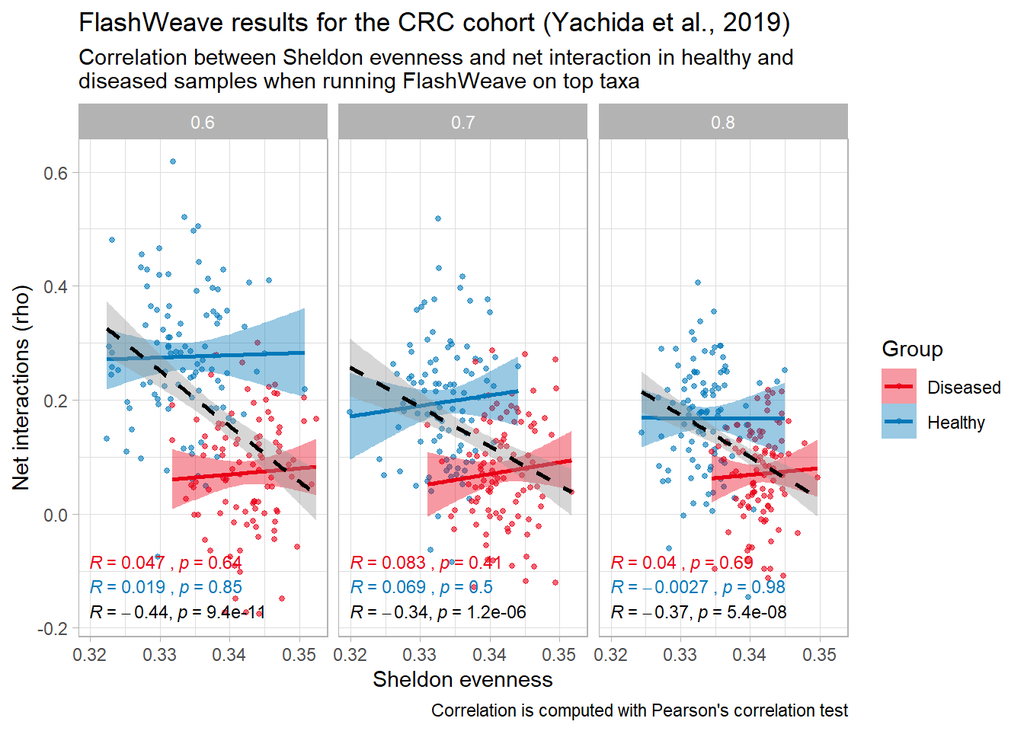

```r
df_res_top |>
  ggplot() +
  aes(x = sheldon, y = rho, color = group, fill = group) +
  geom_point(alpha = 0.6, size = 1) +
  geom_smooth(method = "lm", se = TRUE) +
  geom_smooth(aes(x = sheldon, y = rho), method = "lm",
              se = TRUE, inherit.aes = FALSE,
              color = "black", linetype = "dashed") +
  ggpubr::stat_cor(aes(label = after_stat(paste(r.label, p.label, sep = "~`,`~"))),
                   method = "pearson", label.x.npc = "left", label.y.npc = 0.12,
                   size = 3, show.legend = FALSE) +
  ggpubr::stat_cor(aes(x = sheldon, y = rho), method = "pearson",
                   inherit.aes = FALSE, color = "black",
                   label.x.npc = "left", label.y.npc = 0.01,
                   size = 3) +
  scale_color_manual(values = c("Healthy" = "#0078B9", "Diseased" = "#EA0017")) +
  scale_fill_manual(values  = c("Healthy" = "#0078B9", "Diseased" = "#EA0017")) +
  facet_wrap(~ fraction) +
  labs(x = "Sheldon evenness", y = "Net interactions (rho)", color = "Group", fill = "Group",
       title = "FlashWeave results for the CRC cohort (Yachida et al., 2019)",
       subtitle = "Correlation between Sheldon evenness and net interaction in healthy and \ndiseased samples when running FlashWeave on top taxa",
       caption = "Correlation is computed with Pearson's correlation test")
```

Again, we can see that there is a **significant negative correlation between Sheldon evenness and net interactions** (rho), meaning that samples with higher evenness tend to have a lower net interaction, which is consistent with the results obtained when running FlashWeave on all taxa.

# Network inference with BEEM-Static